# Natural variation of flight

## E. checking assumptions - no outliers vs. outliers

### initial velocity

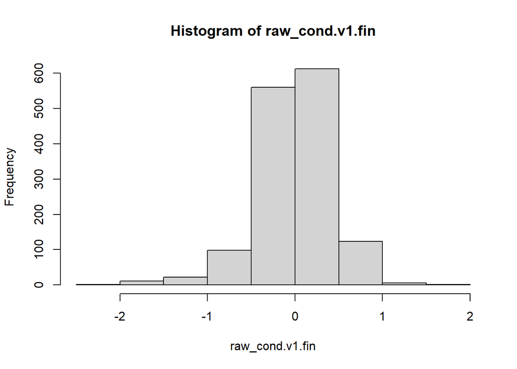

```r
hist(raw_cond.v1.fin) #normality in histogram
```

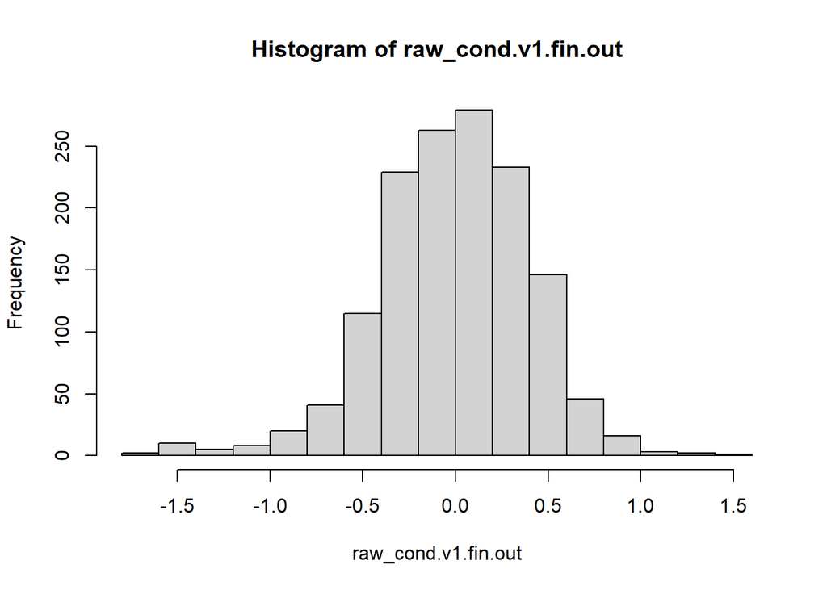

```r
hist(raw_cond.v1.fin.out)
```

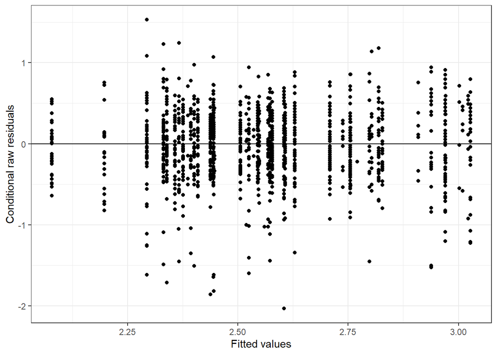

```r
plot_redres(lmer.v1.fin) #heteroskedasticity
```

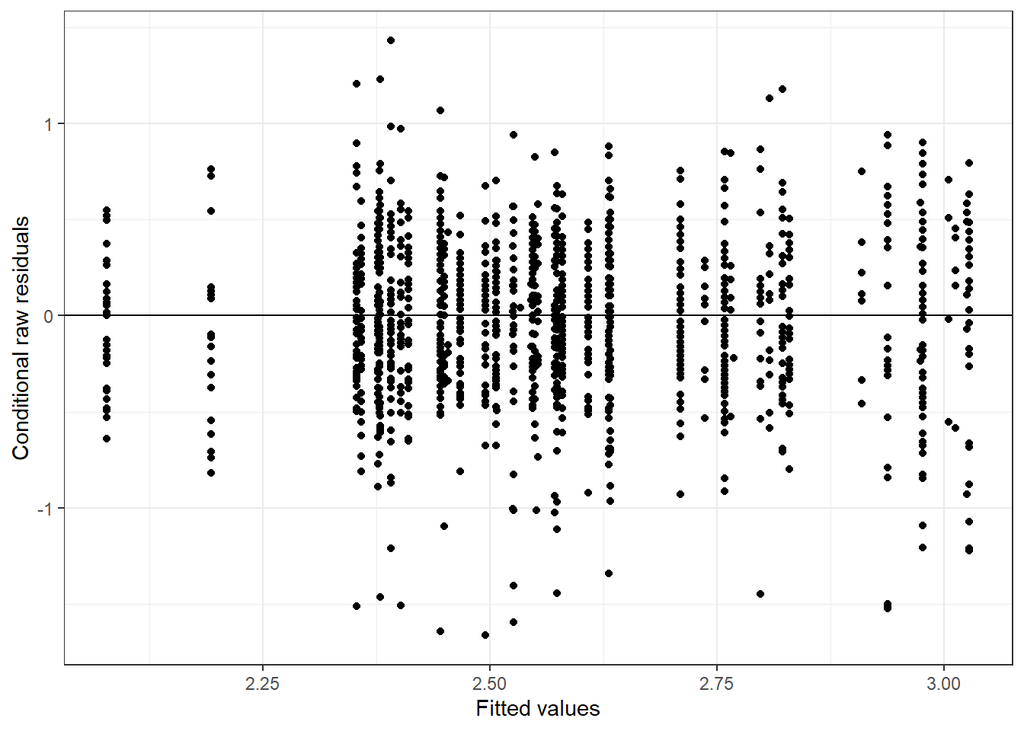

```r
plot_redres(lmer.v1.fin.out)
```

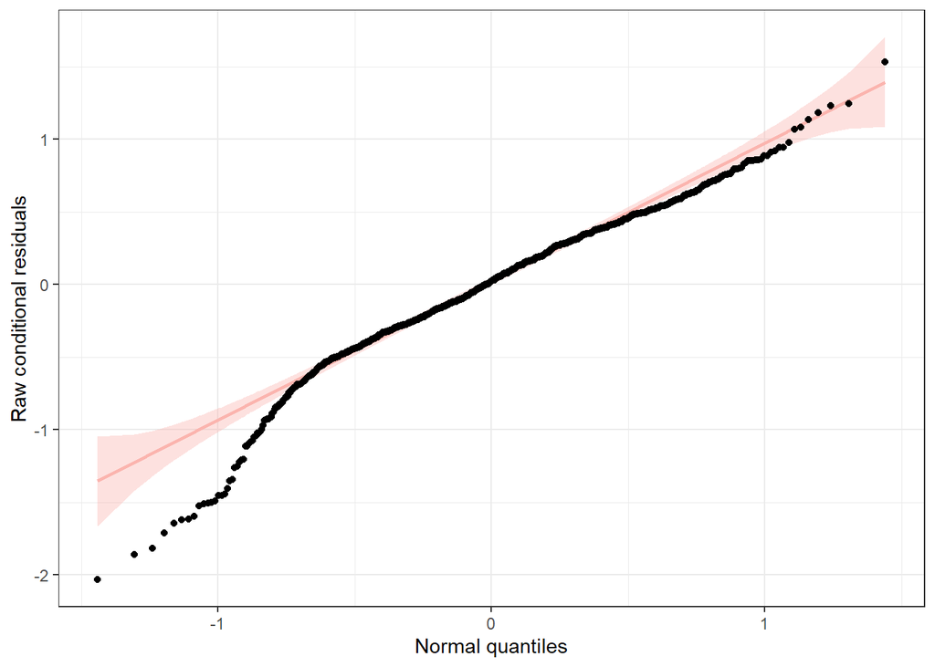

```r
plot_resqq(lmer.v1.fin) #normality of residuals
```

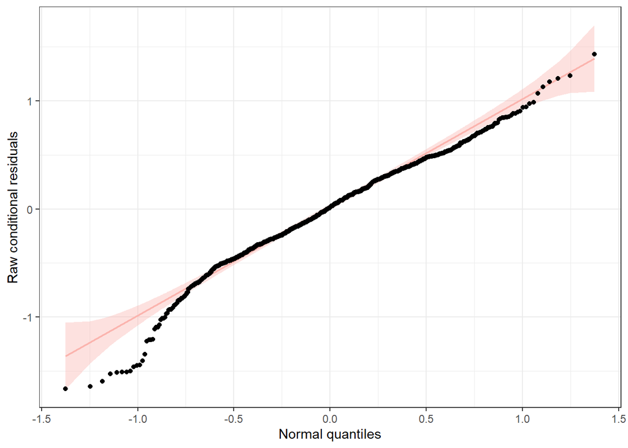

```r
plot_resqq(lmer.v1.fin.out)
```

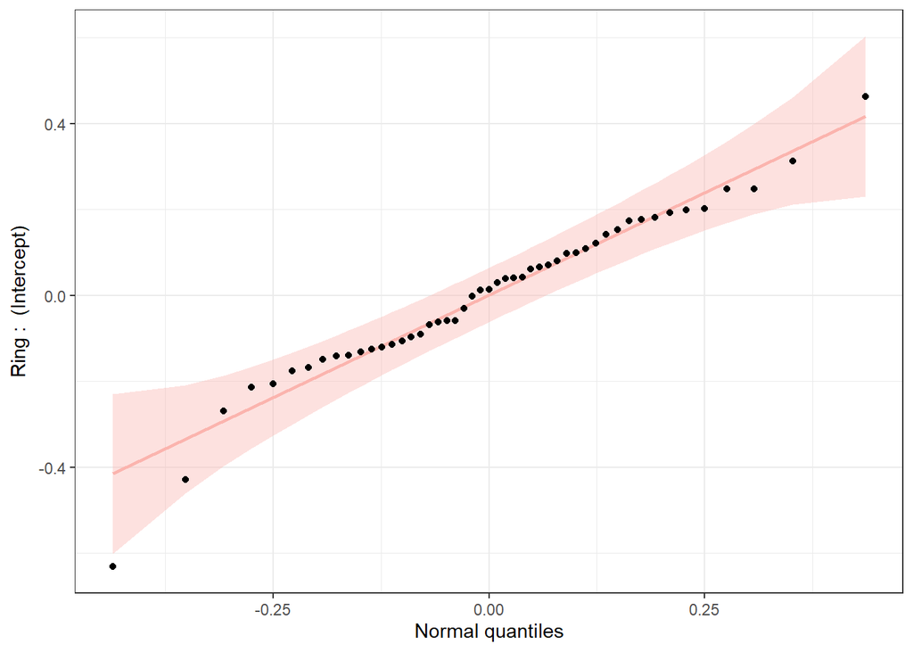

```r
plot_ranef(lmer.v1.fin) #normality of random effects residuals
```

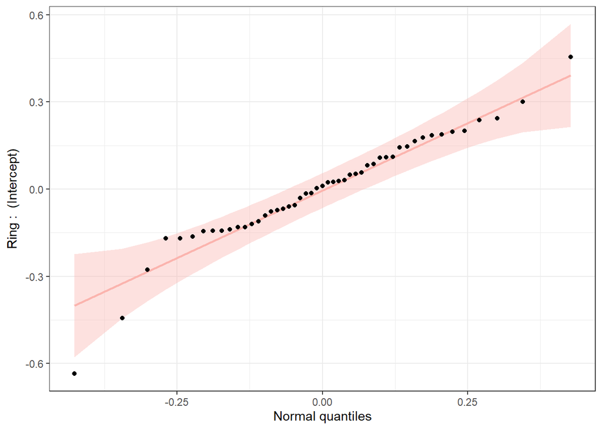

```r
plot_ranef(lmer.v1.fin.out)
```

### end velocity

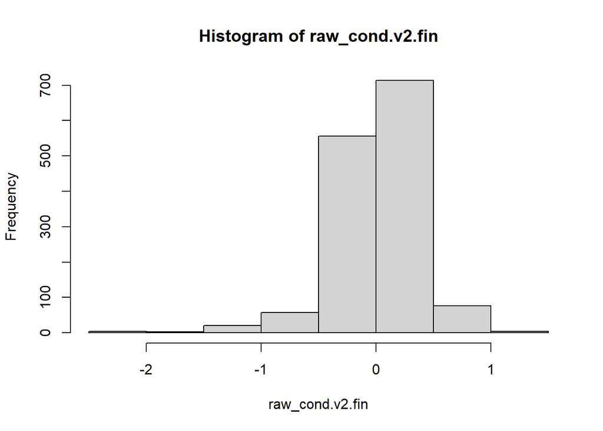

```r
hist(raw_cond.v2.fin) #normality in histogram
```

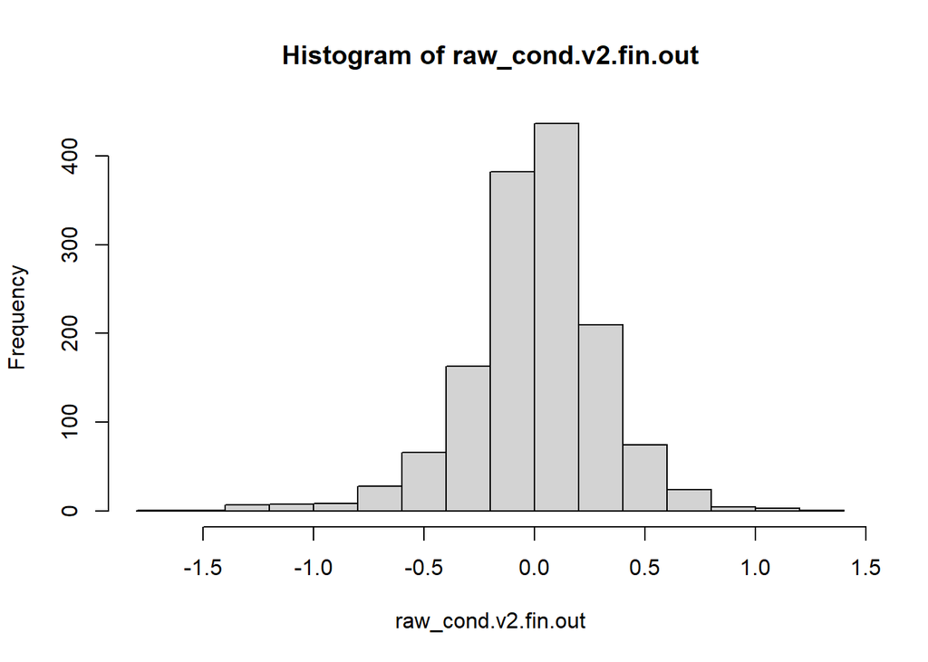

```r
hist(raw_cond.v2.fin.out)
```

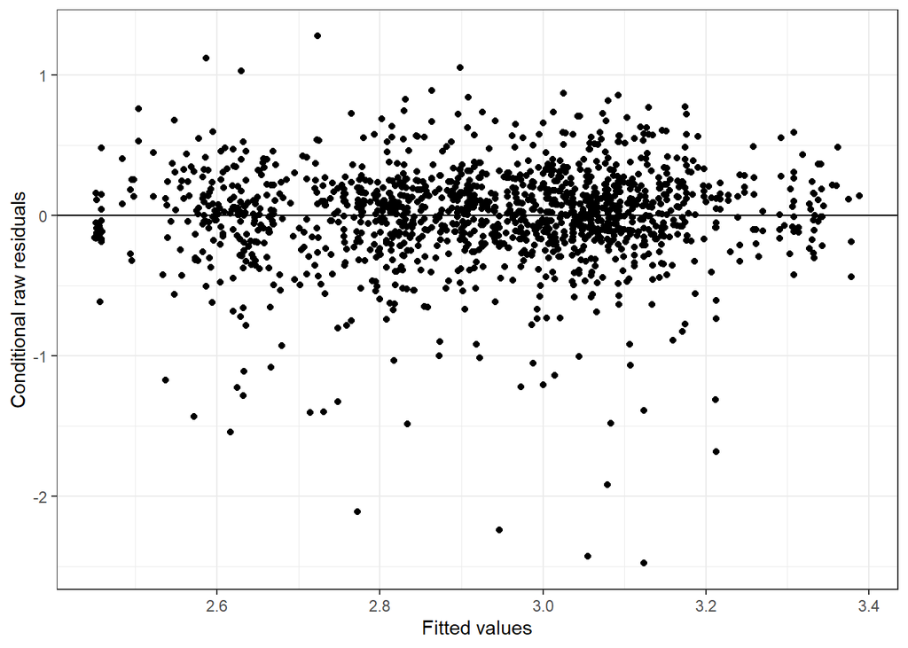

```r
plot_redres(lmer.v2.fin) #heteroskedasticity
```

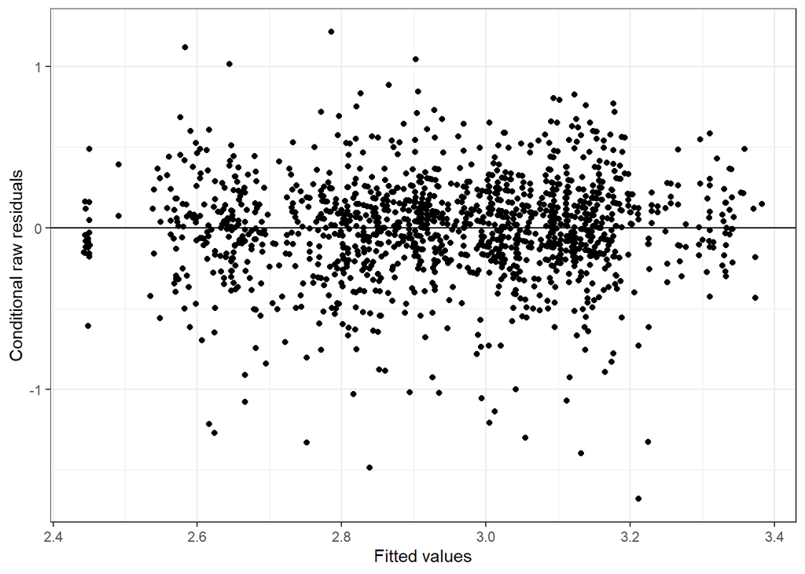

```r
plot_redres(lmer.v2.fin.out)
```

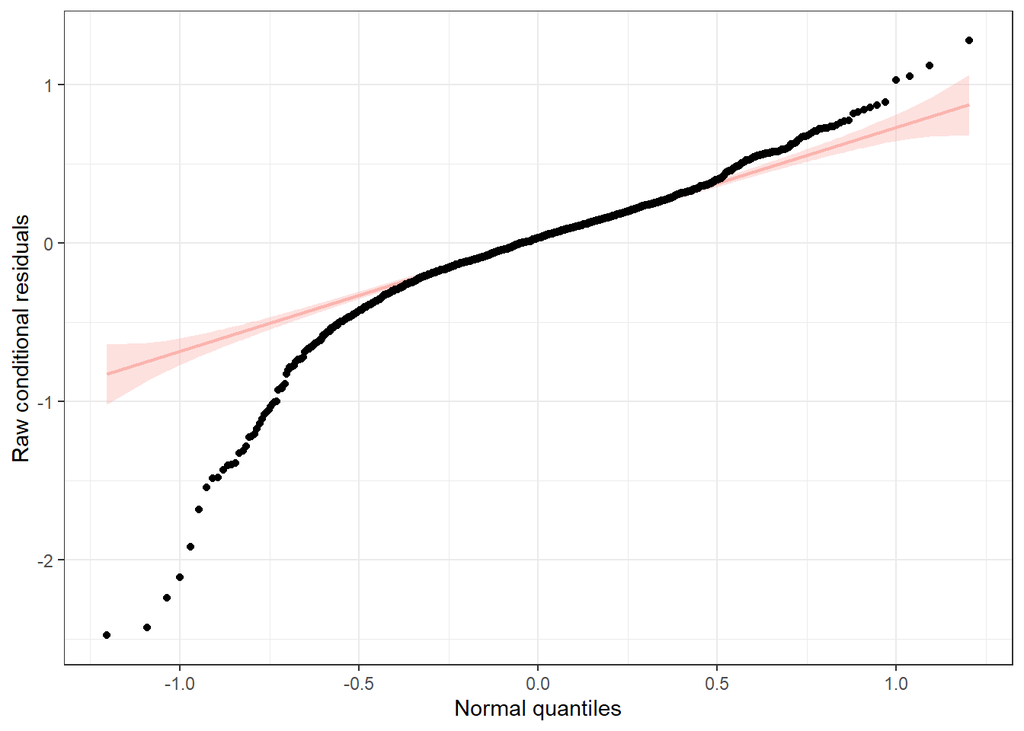

```r
plot_resqq(lmer.v2.fin) #normality of residuals
```

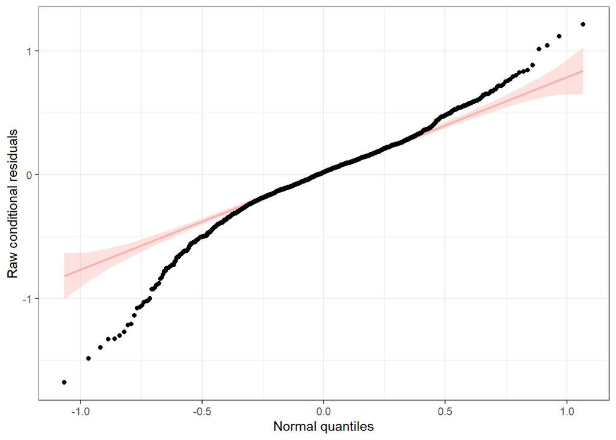

```r
plot_resqq(lmer.v2.fin.out)
```

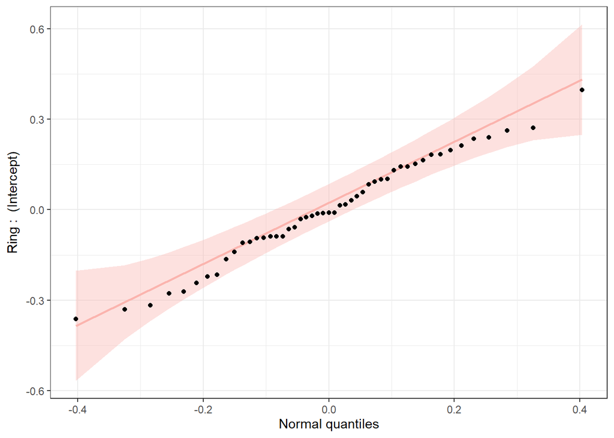

```r
plot_ranef(lmer.v2.fin) #normality of random effects residuals
```

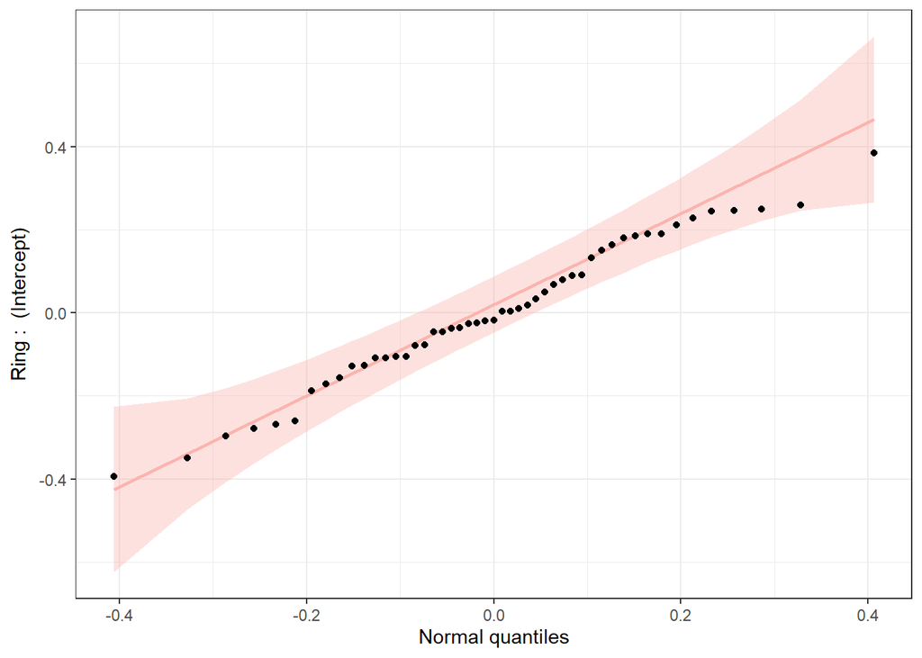

```r
plot_ranef(lmer.v2.fin.out)
```

### average velocity

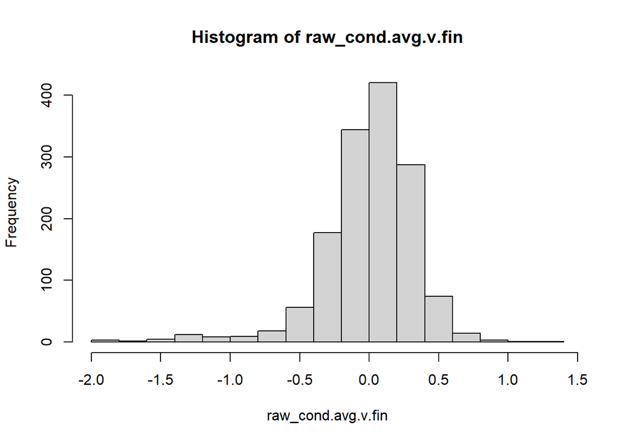

```r
hist(raw_cond.avg.v.fin) #normality in histogram
```

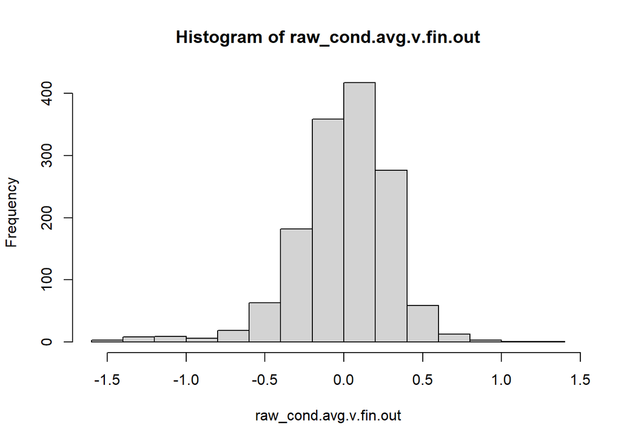

```r
hist(raw_cond.avg.v.fin.out)
```

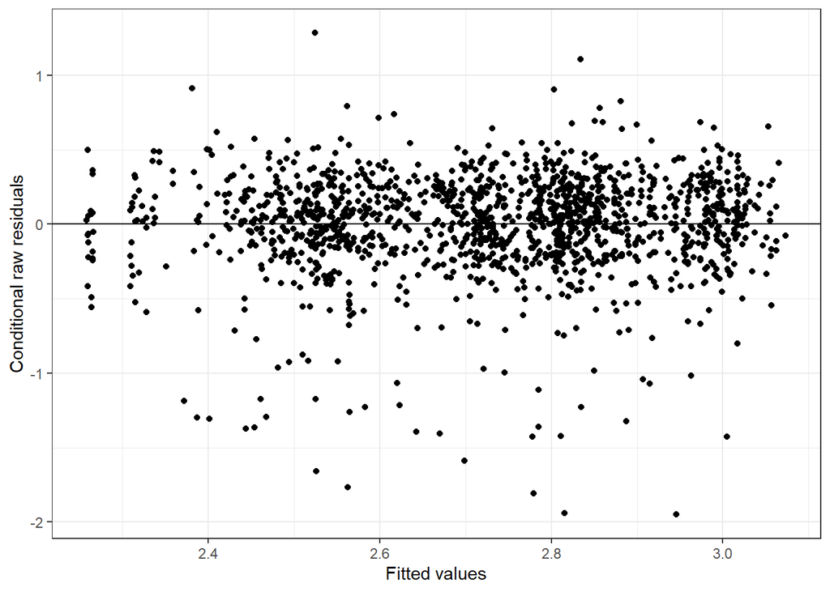

```r
plot_redres(lmer.avg.v.fin) #heteroskedasticity
```

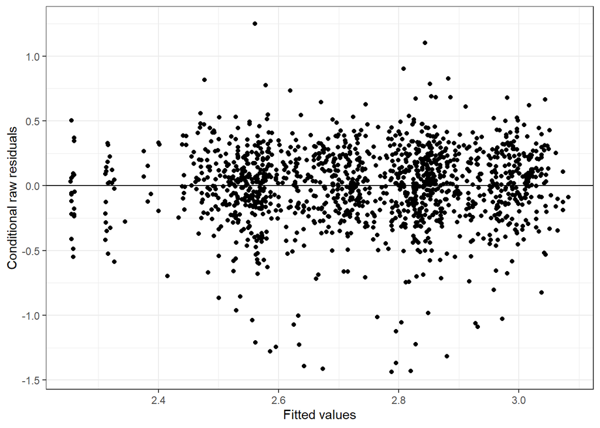

```r
plot_redres(lmer.avg.v.fin.out)
```

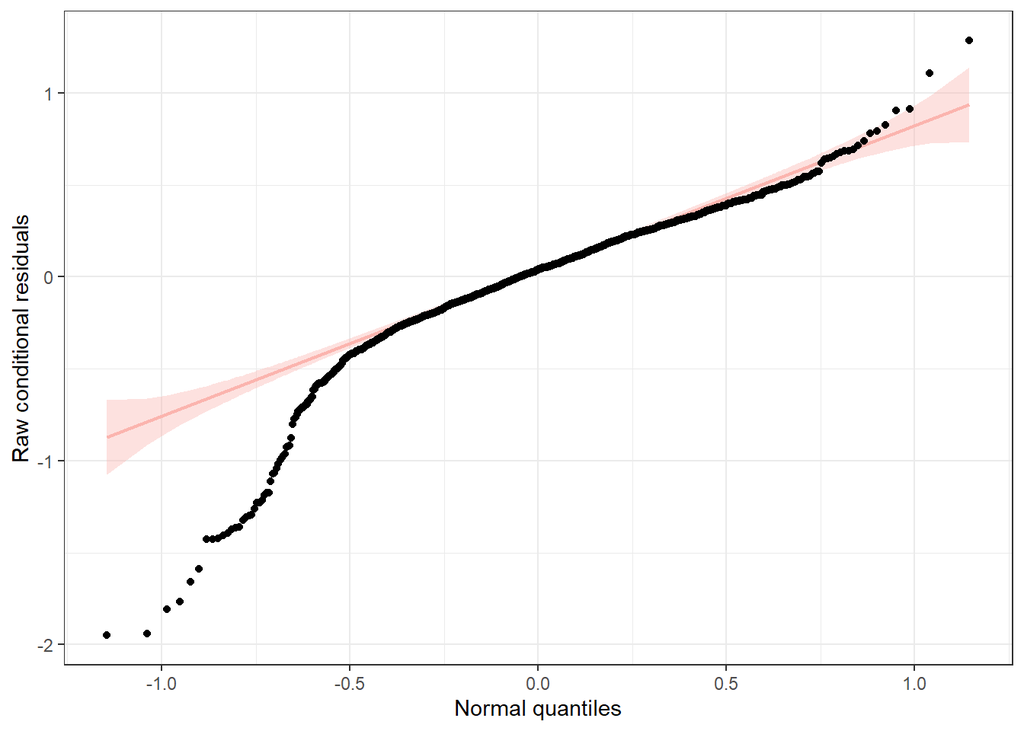

```r
plot_resqq(lmer.avg.v.fin) #normality of residuals
```

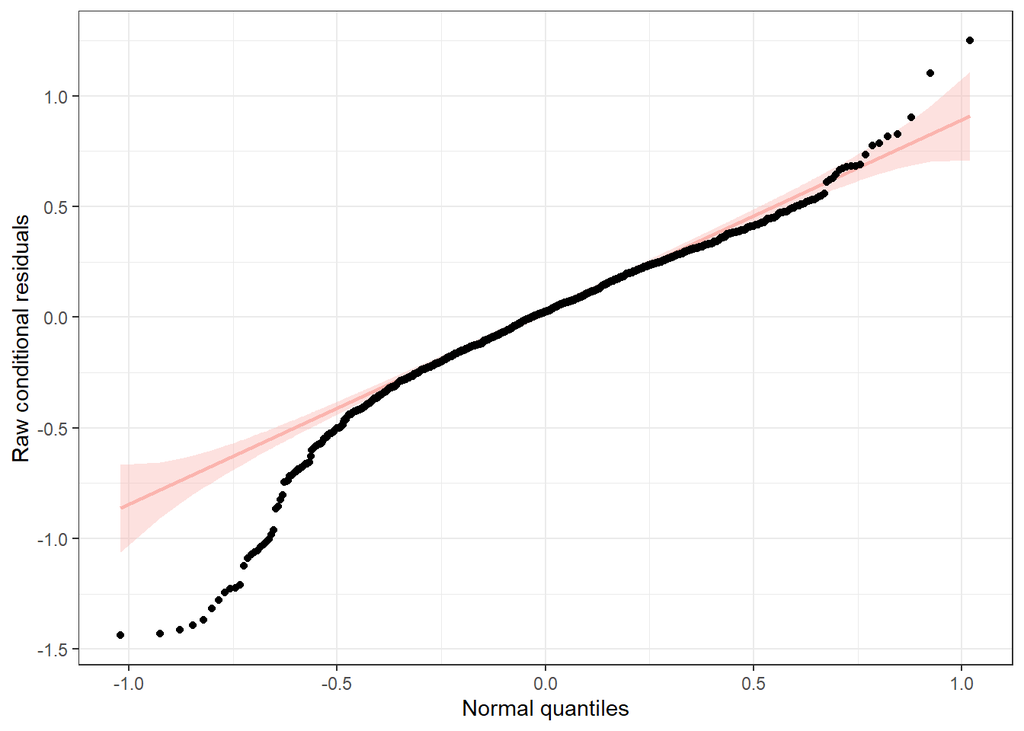

```r
plot_resqq(lmer.avg.v.fin.out)
```

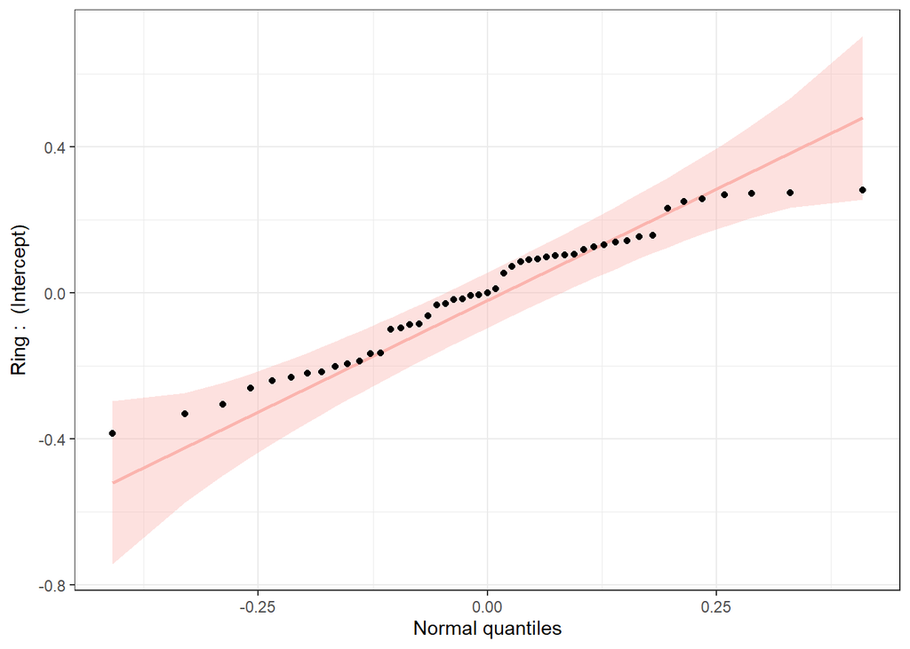

```r
plot_ranef(lmer.avg.v.fin) #normality of random effects residuals
```

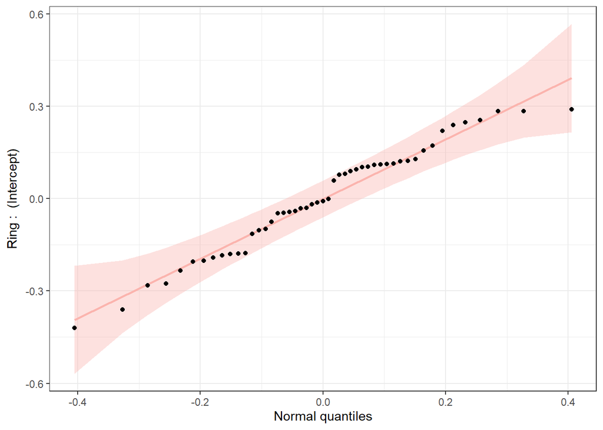

```r
plot_ranef(lmer.avg.v.fin.out)
```

## F. Best model summary

### initial velocity

```r
#contrasts = list(Ring = contr.sum, cgt_day = contr.sum))
Anova(lmer.v1.fin, type = 3, test.statistic = "F") #species
```

```
## Analysis of Deviance Table (Type III Wald F tests with Kenward-Roger df)
##
## Response: v1
##                     F Df Df.res    Pr(>F)
## (Intercept) 3494.6627  1 39.858 < 2.2e-16 ***
## species        6.3849  2 45.683  0.003588 **
## ---
## Signif. codes:  0 '***' 0.001 '**' 0.01 '*' 0.05 '.' 0.1 ' ' 1
```

```r
Anova(lmer.v1.fin.out, type = 3, test.statistic = "F")
```

```
## Analysis of Deviance Table (Type III Wald F tests with Kenward-Roger df)
##
## Response: v1
##                     F Df Df.res    Pr(>F)
## (Intercept) 3720.5816  1 39.989 < 2.2e-16 ***
## species        6.1535  2 45.552  0.004309 **
## ---
## Signif. codes:  0 '***' 0.001 '**' 0.01 '*' 0.05 '.' 0.1 ' ' 1
```

```r
summary(lmer.v1.fin)
```

```
## Linear mixed model fit by REML. t-tests use Satterthwaite's method [
## lmerModLmerTest]
## Formula: v1 ~ species + (1 | Ring)
##    Data: nat.var
##
## REML criterion at convergence: 1751.3
##
## Scaled residuals:
##     Min      1Q  Median      3Q     Max
## -4.7220 -0.5874  0.0470  0.6827  3.5530
##
## Random effects:
##  Groups   Name        Variance Std.Dev.
##  Ring     (Intercept) 0.04864  0.2205
##  Residual             0.18537  0.4305
## Number of obs: 1434, groups:  Ring, 49
##
## Fixed effects:
##              Estimate Std. Error       df t value Pr(>|t|)
## (Intercept)   2.50680    0.04235 38.68447  59.190  < 2e-16 ***
## speciesgreti  0.32179    0.09112 52.30977   3.531 0.000872 ***
## speciesmarti  0.14344    0.12596 38.05612   1.139 0.261922
## ---
## Signif. codes:  0 '***' 0.001 '**' 0.01 '*' 0.05 '.' 0.1 ' ' 1
##
## Correlation of Fixed Effects:
##             (Intr) spcsgr
## speciesgret -0.465
## speciesmart -0.336  0.156
```

```r
tab_model(lmer.v1.fin)
```

|  | v1 |  |  |
| --- | --- | --- | --- |
| Predictors | Estimates | CI | p |
| (Intercept) | 2.51 | 2.42 – 2.59 | **<0.001** |
| species [greti] | 0.32 | 0.14 – 0.50 | **<0.001** |
| species [marti] | 0.14 | -0.10 – 0.39 | 0.255 |
| Random Effects |  |  |  |
| σ<sup>2</sup> | 0.19 |  |  |
| τ<sub>00</sub> <sub>Ring</sub> | 0.05 |  |  |
| ICC | 0.21 |  |  |
| N <sub>Ring</sub> | 49 |  |  |
| Observations | 1434 |  |  |
| Marginal R<sup>2</sup> / Conditional R<sup>2</sup> | 0.042 / 0.241 |  |  |

```r
lsmeans(lmer.v1.fin, pairwise~species)
```

```
## $lsmeans
##  species lsmean     SE   df lower.CL upper.CL
##  bluti     2.51 0.0424 39.9     2.42     2.59
##  greti     2.83 0.0809 59.0     2.67     2.99
##  marti     2.65 0.1190 39.1     2.41     2.89
##
## Degrees-of-freedom method: kenward-roger
## Confidence level used: 0.95
##
## $contrasts
##  contrast      estimate     SE   df t.ratio p.value
##  bluti - greti   -0.322 0.0913 53.9  -3.524  0.0025
##  bluti - marti   -0.143 0.1260 39.2  -1.138  0.4967
##  greti - marti    0.178 0.1440 44.2   1.242  0.4352
##
## Degrees-of-freedom method: kenward-roger
## P value adjustment: tukey method for comparing a family of 3 estimates
```

```r
lsmeans.v1 <- lsmeans(lmer.v1.fin, pairwise~species)
```

### end velocity

```r
Anova(lmer.v2.fin, type = 3, test.statistic = "F") #species and headwind
```

```
## Analysis of Deviance Table (Type III Wald F tests with Kenward-Roger df)
##
## Response: v2
##                    F Df  Df.res    Pr(>F)
## (Intercept) 3857.990  1  160.93 < 2.2e-16 ***
## headwind      21.387  1 1431.16 4.091e-06 ***
## ---
## Signif. codes:  0 '***' 0.001 '**' 0.01 '*' 0.05 '.' 0.1 ' ' 1
```

```r
Anova(lmer.v2.fin.out, type = 3, test.statistic = "F")
```

```
## Analysis of Deviance Table (Type III Wald F tests with Kenward-Roger df)
##
## Response: v2
##                    F Df  Df.res    Pr(>F)
## (Intercept) 4472.346  1  142.06 < 2.2e-16 ***
## headwind      21.269  1 1413.59 4.351e-06 ***
## ---
## Signif. codes:  0 '***' 0.001 '**' 0.01 '*' 0.05 '.' 0.1 ' ' 1
```

```r
summary(lmer.v2.fin)
```

```
## Linear mixed model fit by REML. t-tests use Satterthwaite's method [
## lmerModLmerTest]
## Formula: v2 ~ headwind + (1 | Ring)
##    Data: nat.var
##
## REML criterion at convergence: 1247.6
##
## Scaled residuals:
##     Min      1Q  Median      3Q     Max
## -6.8745 -0.4077  0.0902  0.5318  3.5448
##
## Random effects:
##  Groups   Name        Variance Std.Dev.
##  Ring     (Intercept) 0.03895  0.1973
##  Residual             0.12968  0.3601
## Number of obs: 1434, groups:  Ring, 49
##
## Fixed effects:
##               Estimate Std. Error         df t value Pr(>|t|)
## (Intercept)  2.757e+00  4.433e-02  1.571e+02   62.19  < 2e-16 ***
## headwind    -4.589e-02  9.912e-03  1.431e+03   -4.63 3.99e-06 ***
## ---
## Signif. codes:  0 '***' 0.001 '**' 0.01 '*' 0.05 '.' 0.1 ' ' 1
##
## Correlation of Fixed Effects:
##          (Intr)
## headwind 0.700
```

### average velocity

```r
Anova(lmer.avg.v.fin, type = 3, test.statistic = "F") #species and headwind
```

```
## Analysis of Deviance Table (Type III Wald F tests with Kenward-Roger df)
##
## Response: avg.v
##                    F Df  Df.res    Pr(>F)
## (Intercept) 3587.828  1  149.85 < 2.2e-16 ***
## headwind      17.223  1 1429.98  3.52e-05 ***
## ---
## Signif. codes:  0 '***' 0.001 '**' 0.01 '*' 0.05 '.' 0.1 ' ' 1
```

```r
Anova(lmer.avg.v.fin.out, type = 3, test.statistic = "F")
```

```
## Analysis of Deviance Table (Type III Wald F tests with Kenward-Roger df)
##
## Response: avg.v
##                    F Df  Df.res    Pr(>F)
## (Intercept) 4221.690  1  135.54 < 2.2e-16 ***
## headwind      13.393  1 1412.39 0.0002619 ***
## ---
## Signif. codes:  0 '***' 0.001 '**' 0.01 '*' 0.05 '.' 0.1 ' ' 1
```

```r
summary(lmer.avg.v.fin)
```

```
## Linear mixed model fit by REML. t-tests use Satterthwaite's method [
## lmerModLmerTest]
## Formula: avg.v ~ headwind + (1 | Ring)
##    Data: nat.var
##
## REML criterion at convergence: 1109.9
##
## Scaled residuals:
##     Min      1Q  Median      3Q     Max
## -5.6928 -0.4278  0.1154  0.6222  3.7496
##
## Random effects:
##  Groups   Name        Variance Std.Dev.
##  Ring     (Intercept) 0.03948  0.1987
##  Residual             0.11744  0.3427
## Number of obs: 1434, groups:  Ring, 49
##
## Fixed effects:
##               Estimate Std. Error         df t value Pr(>|t|)
## (Intercept)  2.595e+00  4.328e-02  1.428e+02  59.969  < 2e-16 ***
## headwind    -3.924e-02  9.444e-03  1.430e+03  -4.155 3.45e-05 ***
## ---
## Signif. codes:  0 '***' 0.001 '**' 0.01 '*' 0.05 '.' 0.1 ' ' 1
##
## Correlation of Fixed Effects:
##          (Intr)
## headwind 0.683
```

### acceleration

```r
Anova(lmer.acc.fin, type = 3, test.statistic = "F") #species and Sex
```

```
## Analysis of Deviance Table (Type III Wald F tests with Kenward-Roger df)
##
## Response: acc
##                   F Df Df.res    Pr(>F)
## (Intercept) 16.0819  1 28.151 0.0004057 ***
## species     12.7559  2 39.110 5.436e-05 ***
## Sex          0.6363  2 33.651 0.5354960
## ---
## Signif. codes:  0 '***' 0.001 '**' 0.01 '*' 0.05 '.' 0.1 ' ' 1
```

```r
Anova(lmer.acc.fin.out, type = 3, test.statistic = "F")
```

```
## Analysis of Deviance Table (Type III Wald F tests with Kenward-Roger df)
##
## Response: acc
##                  F Df Df.res    Pr(>F)
## (Intercept) 15.522  1 28.253 0.0004878 ***
## species     13.214  2 39.044 4.141e-05 ***
## Sex          0.493  2 33.764 0.6150967
## ---
## Signif. codes:  0 '***' 0.001 '**' 0.01 '*' 0.05 '.' 0.1 ' ' 1
```

```r
summary(lmer.acc.fin)
```

```
## Linear mixed model fit by REML. t-tests use Satterthwaite's method [
## lmerModLmerTest]
## Formula: acc ~ species + Sex + (1 | Ring)
##    Data: nat.var
##
## REML criterion at convergence: 8282.7
##
## Scaled residuals:
##     Min      1Q  Median      3Q     Max
## -4.3766 -0.6433  0.0123  0.6439  3.4045
##
## Random effects:
##  Groups   Name        Variance Std.Dev.
##  Ring     (Intercept)  2.162   1.470
##  Residual             18.181   4.264
## Number of obs: 1434, groups:  Ring, 49
##
## Fixed effects:
##              Estimate Std. Error      df t value Pr(>|t|)
## (Intercept)    4.4944     1.1206 27.0775   4.011 0.000429 ***
## speciesgreti  -3.2851     0.6995 50.4970  -4.696 2.07e-05 ***
## speciesmarti  -2.6814     1.4065 29.5907  -1.906 0.066347 .
## SexF          -0.5125     1.1964 27.9608  -0.428 0.671682
## SexM          -1.0269     1.1977 28.0081  -0.857 0.398506
## ---
## Signif. codes:  0 '***' 0.001 '**' 0.01 '*' 0.05 '.' 0.1 ' ' 1
##
## Correlation of Fixed Effects:
##             (Intr) spcsgr spcsmr SexF
## speciesgret  0.000
## speciesmart -0.797  0.000
## SexF        -0.937 -0.089  0.746
## SexM        -0.936 -0.149  0.745  0.891
```

```r
tab_model(lmer.acc.fin)
```

|  | acc |  |  |
| --- | --- | --- | --- |
| Predictors | Estimates | CI | p |
| (Intercept) | 4.49 | 2.30 – 6.69 | **<0.001** |
| species [greti] | -3.29 | -4.66 – -1.91 | **<0.001** |
| species [marti] | -2.68 | -5.44 – 0.08 | 0.057 |
| Sex [F] | -0.51 | -2.86 – 1.83 | 0.668 |
| Sex [M] | -1.03 | -3.38 – 1.32 | 0.391 |
| Random Effects |  |  |  |
| σ<sup>2</sup> | 18.18 |  |  |
| τ<sub>00</sub> <sub>Ring</sub> | 2.16 |  |  |
| ICC | 0.11 |  |  |
| N <sub>Ring</sub> | 49 |  |  |
| Observations | 1434 |  |  |
| Marginal R<sup>2</sup> / Conditional R<sup>2</sup> | 0.062 / 0.161 |  |  |

```r
lsmeans(lmer.acc.fin, pairwise~species)
```

```
## $lsmeans
##  species lsmean    SE   df lower.CL upper.CL
##  bluti    3.981 0.429 29.6    3.105     4.86
##  greti    0.696 0.737 46.9   -0.787     2.18
##  marti    1.300 1.150 32.4   -1.044     3.64
##
## Results are averaged over the levels of: Sex
## Degrees-of-freedom method: kenward-roger
## Confidence level used: 0.95
##
## $contrasts
##  contrast      estimate    SE   df t.ratio p.value
##  bluti - greti    3.285 0.702 52.5   4.679  0.0001
##  bluti - marti    2.681 1.410 30.8   1.906  0.1541
##  greti - marti   -0.604 1.570 33.8  -0.384  0.9221
##
## Results are averaged over the levels of: Sex
## Degrees-of-freedom method: kenward-roger
## P value adjustment: tukey method for comparing a family of 3 estimates
```

```r
lsmeans.acc <- lsmeans(lmer.acc.fin, pairwise~species)
```

## G. plotting species difference

### v1

```r
plot.v1.means <- data.frame(lsmeans.v1$lsmeans)

plot.v1.lsmeans <-
  ggplot() +
  geom_point(data = plot.v1.means, aes(x = species, y = lsmean, color = species), alpha = 1) +
  geom_errorbar(data = plot.v1.means, aes(x = species, ymin = lower.CL, ymax = upper.CL, color = species, width = 0.5),alpha = 1) +
  scale_color_manual(values = c("bluti" ="black", "greti" = "black", "marti" = "black")) +
  scale_x_discrete(labels = c("Blue Tit","Great Tit","Marsh Tit")) +
  ylab(expression(initial~velocity~(m/s))) +
  ylim(2.25,3.25)+
  theme(axis.title.x=element_blank()) + #getting rid of x-axis title
  theme(legend.position = "none")  #getting rid of legend
```

### acc

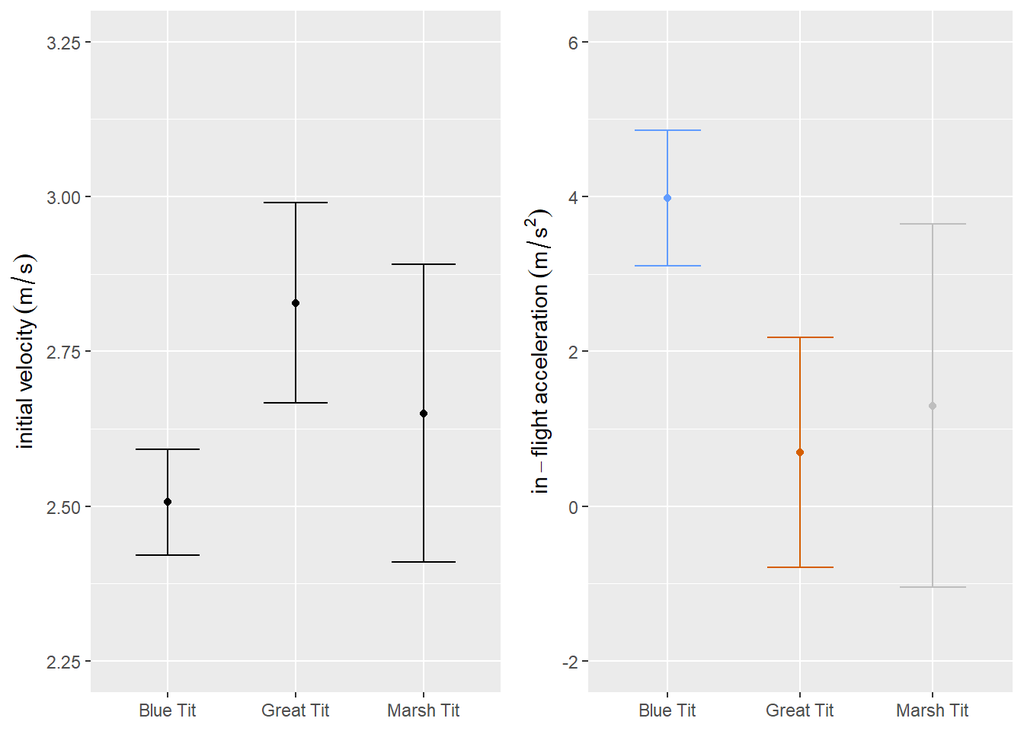

```r
plot.acc.means <- data.frame(lsmeans.acc$lsmeans)

plot.acc.lsmeans <-
  ggplot() +
  geom_point(data = plot.acc.means, aes(x = species, y = lsmean, color = species), alpha = 1) +
  geom_errorbar(data = plot.acc.means, aes(x = species, ymin = lower.CL, ymax = upper.CL, color = species, width = 0.5),alpha = 1) +
  scale_color_manual(values = c("bluti" = "#619CFF", "greti" = "#D55E00", "marti" = "grey")) +
  scale_x_discrete(labels = c("Blue Tit","Great Tit","Marsh Tit")) +
  ylab(expression(`in`-flight~acceleration~(m/s^2))) +
  ylim(-2,6) +
  theme(axis.title.x=element_blank()) + #getting rid of x-axis title
  theme(legend.position = "none") #getting rid of legend

grid.arrange(plot.v1.lsmeans, plot.acc.lsmeans, nrow = 1)
```

### tarsus length

```r
species_tarsus <- nat.var %>% group_by(species) %>%
  summarise(
    Mean_Tarsus = mean(Tarsus, na.rm = TRUE),
    SD_Tarsus = sd(Tarsus, na.rm = TRUE)
  )

species_tarsus
```

```
## # A tibble: 3 × 3
##   species Mean_Tarsus SD_Tarsus
##   <chr>         <dbl>     <dbl>
## 1 bluti          19.2     0.677
## 2 greti          23.0     0.441
## 3 marti          18.5     0.203
```

# V. Repeatability

## v1

### repeatability

```r
v1.rpt <- rpt(v1 ~ species + (1|Ring), data = nat.var, grname = "Ring", datatype = "Gaussian", nboot = 10000, npermut = 0)
```

```
## Bootstrap Progress:
```

```r
v1.rpt
```

```
##
##
## Repeatability estimation using the lmm method
##
## Repeatability for Ring
## R  = 0.208
## SE = 0.043
## CI = [0.125, 0.295]
## P  = 1.16e-45 [LRT]
##      NA [Permutation]
```

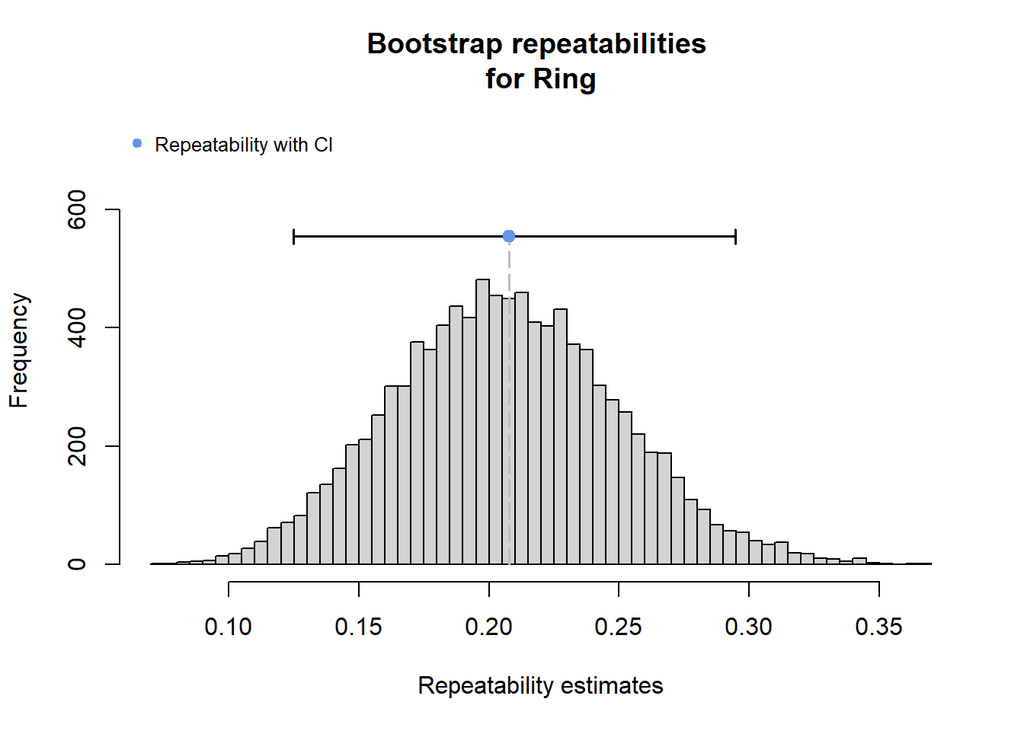

```r
plot.v1.rpt <- plot(v1.rpt)
```

#### variance

```r
v1.var <- rpt(v1 ~ species  + Sex + (1|Ring), data = nat.var,grname = "Ring", datatype = "Gaussian", nboot = 10000, npermut = 0,ratio = FALSE)
```

```
## Bootstrap Progress:
```

```r
v1.var
```

```
##
##
## Variance estimation using the lmm method
##
## Variance of Ring
## Var = 0.049
## SE = 0.013
## CI = [0.026, 0.078]
## P  = 5.99e-41 [LRT]
##      NA [Permutation]
```

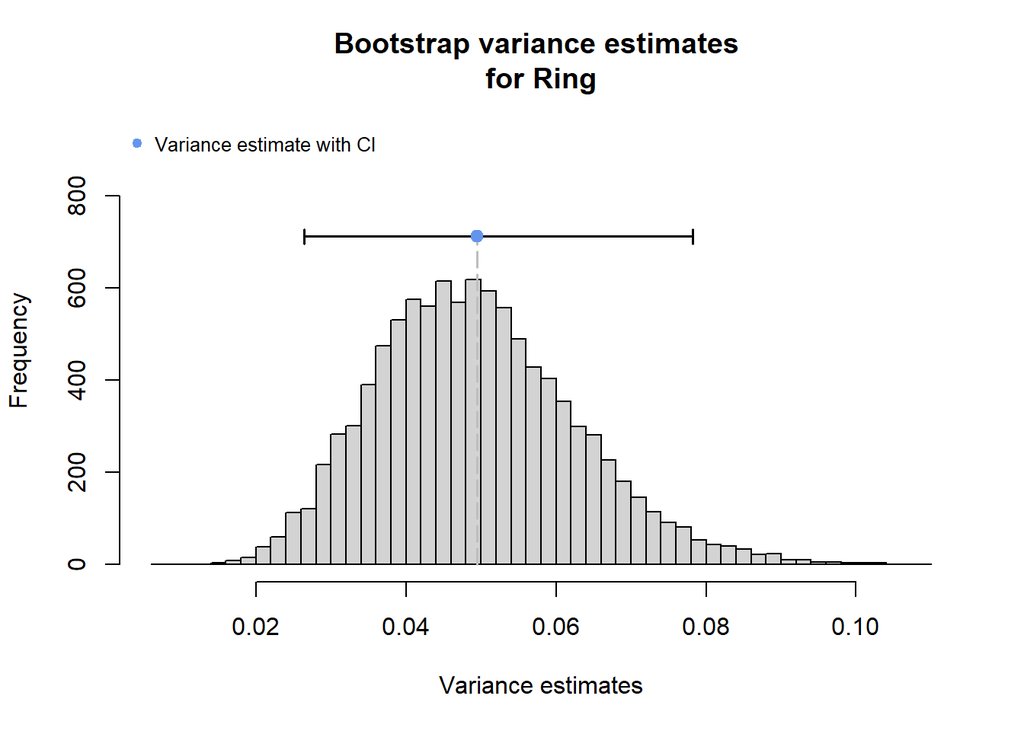

```r
plot.v1.var <- plot(v1.var)
```

```r
acc.rpt <- rpt(acc ~ species  + Sex + (1|Ring), data = nat.var,grname = "Ring", datatype = "Gaussian", nboot = 10000, npermut = 0)
```

```
## Bootstrap Progress:
```

```r
acc.rpt
```

```
##
##
## Repeatability estimation using the lmm method
##
## Repeatability for Ring
## R  = 0.106
## SE = 0.029
## CI = [0.052, 0.167]
## P  = 1.74e-20 [LRT]
##      NA [Permutation]
```

### variance

```r
acc.var <- rpt(acc ~ species  + Sex + (1|Ring), data = nat.var,grname = "Ring", datatype = "Gaussian", nboot = 10000, npermut = 0,ratio = FALSE)
```

```
## Bootstrap Progress:
```

```r
acc.var
```

```
##
##
## Variance estimation using the lmm method
##
## Variance of Ring
## Var = 2.162
## SE = 0.673
## CI = [1.01, 3.618]
## P  = 1.74e-20 [LRT]
##      NA [Permutation]
```

## PLOTS

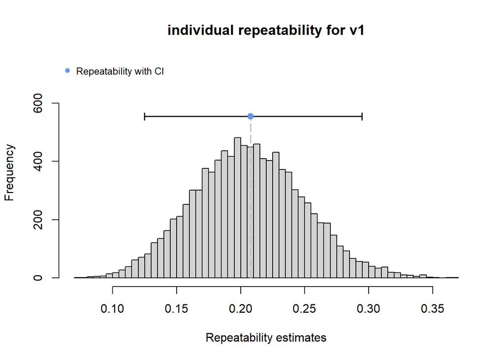

```r
plot(v1.rpt, main = "individual repeatability for v1")
```

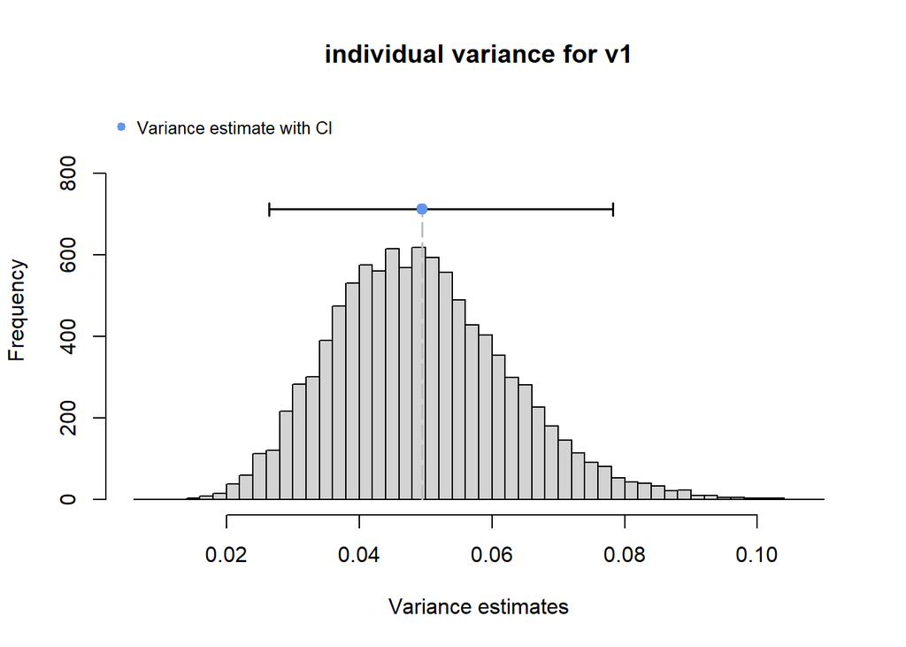

```r
plot(v1.var, main = "individual variance for v1")
```

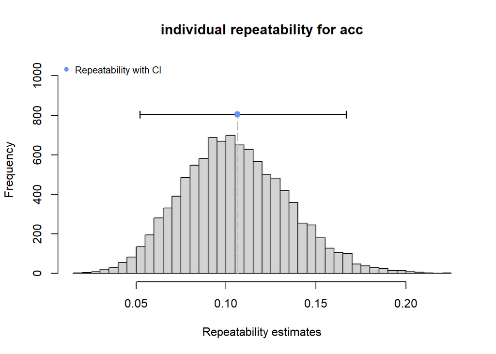

```r
plot(acc.rpt, main = "individual repeatability for acc")
```

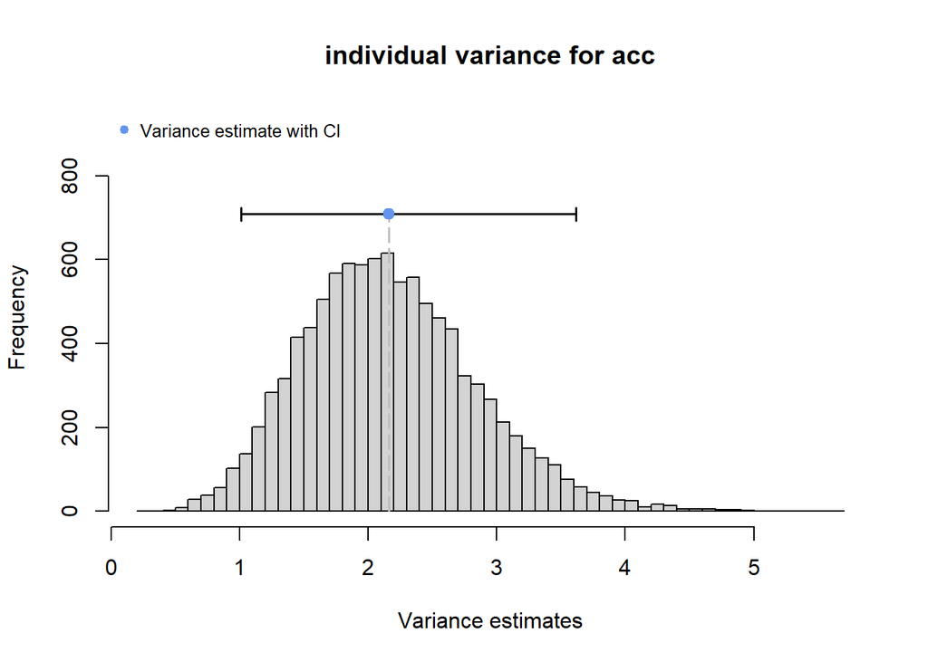

```r
plot(acc.var, main = "individual variance for acc")
```

# VI. Response to reviewers

## 1. Raw data graph of individual & species variance

### v1

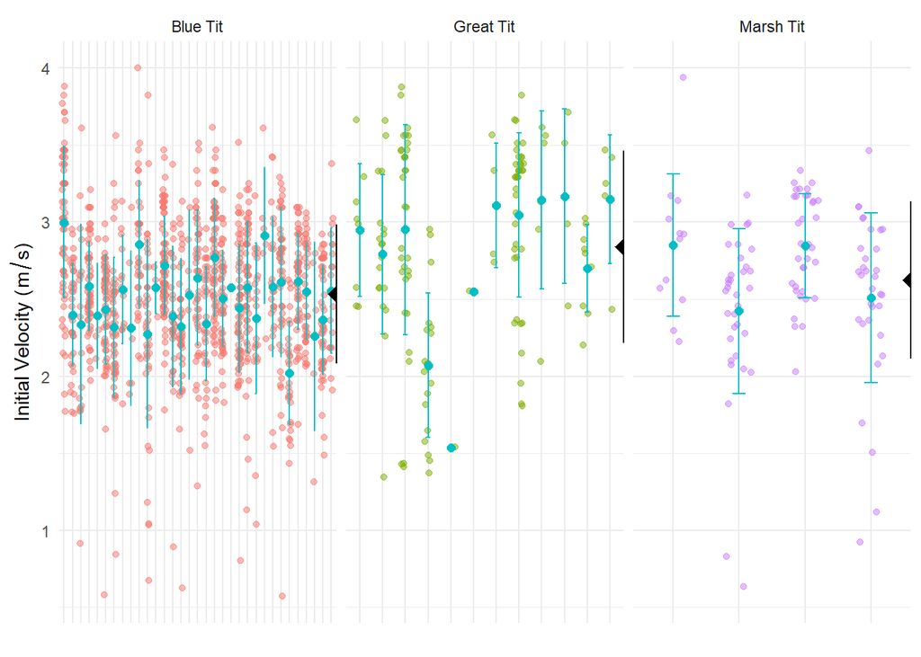

```r
# Calculate summary statistics: mean and ±1 SD per individual
summary_df <- nat.var %>%
  group_by(Ring, species) %>%
  summarise(
    mean_v1 = mean(v1, na.rm = TRUE),
    sd_v1 = sd(v1, na.rm = TRUE),
    .groups = 'drop'
  ) %>%
  mutate(
    sd_lower = mean_v1 - sd_v1,
    sd_upper = mean_v1 + sd_v1
  )

species_summary <- nat.var %>%
  group_by(species) %>%
  summarise(
    mean_v1 = mean(v1, na.rm = TRUE),
    sd_v1 = sd(v1, na.rm = TRUE),
    .groups = 'drop'
  ) %>%
  mutate(
    sd_lower = mean_v1 - sd_v1,
    sd_upper = mean_v1 + sd_v1
  )

# Plot
v1_var_graph <- ggplot(nat.var, aes(x = Ring, y = v1, color = species)) +
  geom_jitter(width = 0.2, alpha = 0.5) +  # individual v1 dots
  geom_point(data = summary_df, aes(x=Ring, y = mean_v1, color ="grey"), size = 2, shape = 16, inherit.aes = FALSE) +  # mean points
  geom_errorbar(data = summary_df, aes(x=Ring, ymin = sd_lower, ymax = sd_upper, color = "grey"), width = 0.2, inherit.aes = FALSE) +  # ±1 SD

# Species-level overlaying in black
  geom_point(data = species_summary, aes(x = Inf-0.5, y = mean_v1), color = "black", size = 4, shape = 18, inherit.aes = FALSE) +
  geom_errorbar(data = species_summary, aes(x = Inf-0.5, ymin = sd_lower, ymax = sd_upper), color = "black", width = 0.4, inherit.aes = FALSE) +
  facet_wrap(~ species, scales = "free_x", labeller = labeller(
  species = c(
    "bluti" = "Blue Tit",
    "greti" = "Great Tit",
    "marti" = "Marsh Tit" ))) +  # group by species
  theme_minimal() +
  labs(
    x ="",
    y = expression("Initial Velocity ("*m/s*")"),
  ) +
  theme(axis.text.x = element_text(angle = 45, hjust = 1)) +
  theme(
  axis.text.x = element_blank(),     # hides x-axis labels
  axis.ticks.x = element_blank(),    # hides x-axis ticks
  legend.position = "none"
)

v1_var_graph
```

### acc

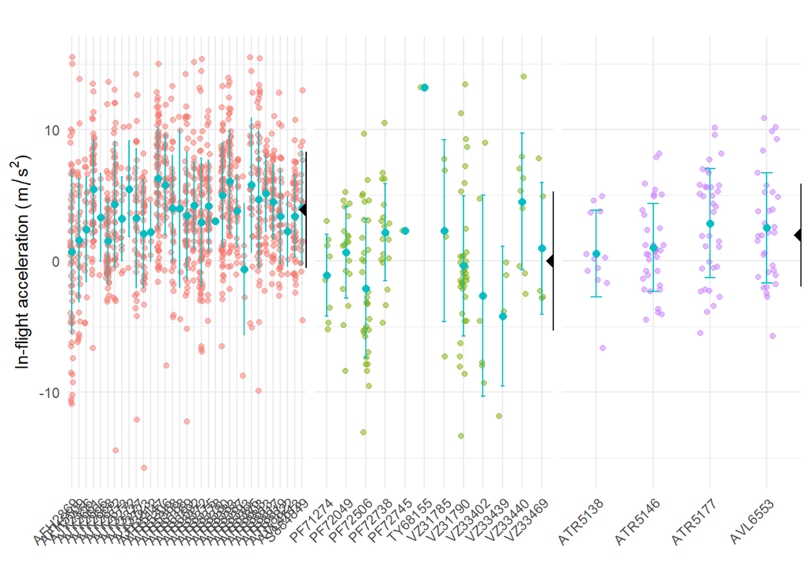

```r
summary_df <- nat.var %>%
  group_by(Ring, species) %>%
  summarise(
    mean_acc = mean(acc, na.rm = TRUE),
    sd_acc = sd(acc, na.rm = TRUE),
    .groups = 'drop'
  ) %>%
  mutate(
    sd_lower = mean_acc - sd_acc,
    sd_upper = mean_acc + sd_acc
  )

species_summary <- nat.var %>%
  group_by(species) %>%
  summarise(
    mean_acc = mean(acc, na.rm = TRUE),
    sd_acc = sd(acc, na.rm = TRUE),
    .groups = 'drop'
  ) %>%
  mutate(
    sd_lower = mean_acc - sd_acc,
    sd_upper = mean_acc + sd_acc
  )

# Plot
acc_var_graph <- ggplot(nat.var, aes(x = Ring, y = acc, color = species)) +
  geom_jitter(width = 0.2, alpha = 0.5) +  # individual v1 dots
  geom_point(data = summary_df, aes(x=Ring, y = mean_acc, color ="grey"), size = 2, shape = 16, inherit.aes = FALSE) +  # mean points
  geom_errorbar(data = summary_df, aes(x=Ring, ymin = sd_lower, ymax = sd_upper, color = "grey"), width = 0.2, inherit.aes = FALSE) +  # ±1 SD

# Species-level overlaying in black
  geom_point(data = species_summary, aes(x = Inf-0.5, y = mean_acc), color = "black", size = 4, shape = 18, inherit.aes = FALSE) +
  geom_errorbar(data = species_summary, aes(x = Inf-0.5, ymin = sd_lower, ymax = sd_upper), color = "black", width = 0.4, inherit.aes = FALSE) +
  facet_wrap(~ species, scales = "free_x", labeller = labeller(
  species = c(
    "bluti" = "",
    "greti" = "",
    "marti" = "" ))) +
  theme_minimal() +
  labs(
    x = "",
    y = expression("In-flight acceleration ("*m/s^2*")")
  ) +
  theme(axis.text.x = element_text(angle = 45, hjust = 1)) +
  theme(
   # hides x-axis ticks
  axis.text.x = element_text(angle = 45),
  legend.position = "none"
)

acc_var_graph
```

### v1

#### headwind

```r
Anova(lmer(v1 ~ species  + Sex  + age + headwind + (1|Ring), data = nat.var), type = 3, test.statistic = "F")
```

```
## Analysis of Deviance Table (Type III Wald F tests with Kenward-Roger df)
##
## Response: v1
##                   F Df  Df.res    Pr(>F)
## (Intercept) 28.4455  1   38.40 4.535e-06 ***
## species      5.2844  2   39.36  0.009271 **
## Sex          0.8987  2   37.82  0.415607
## age          0.5107  1   39.19  0.479092
## headwind     6.3128  1 1426.67  0.012097 *
## ---
## Signif. codes:  0 '***' 0.001 '**' 0.01 '*' 0.05 '.' 0.1 ' ' 1
```

```r
summary(lmer(v1 ~ species  + Sex  + age + headwind + (1|Ring), data = nat.var), type = 3)
```

```
## Linear mixed model fit by REML. t-tests use Satterthwaite's method [
## lmerModLmerTest]
## Formula: v1 ~ species + Sex + age + headwind + (1 | Ring)
##    Data: nat.var
##
## REML criterion at convergence: 1758
##
## Scaled residuals:
##     Min      1Q  Median      3Q     Max
## -4.7733 -0.5704  0.0319  0.6843  3.6922
##
## Random effects:
##  Groups   Name        Variance Std.Dev.
##  Ring     (Intercept) 0.04701  0.2168
##  Residual             0.18492  0.4300
## Number of obs: 1434, groups:  Ring, 49
##
## Fixed effects:
##                Estimate Std. Error         df t value Pr(>|t|)
## (Intercept)     2.61814    0.48981   37.62403   5.345 4.62e-06 ***
## speciesgreti    0.29136    0.09436   47.63723   3.088  0.00336 **
## speciesmarti    0.24144    0.20164   32.13434   1.197  0.23991
## SexF            0.08348    0.17033   31.36064   0.490  0.62744
## SexM            0.16914    0.16906   31.37191   1.000  0.32473
## age            -0.06016    0.08399   38.39480  -0.716  0.47813
## headwind       -0.02975    0.01182 1426.66455  -2.516  0.01197 *
## ---
## Signif. codes:  0 '***' 0.001 '**' 0.01 '*' 0.05 '.' 0.1 ' ' 1
##
## Correlation of Fixed Effects:
##             (Intr) spcsgr spcsmr SexF   SexM   age
## speciesgret -0.227
## speciesmart -0.450  0.049
## SexF        -0.422 -0.056  0.762
## SexM        -0.300 -0.149  0.741  0.894
## age         -0.943  0.238  0.205  0.126 -0.006
## headwind     0.089 -0.036 -0.011 -0.011  0.005 -0.013
```

```r
min(nat.var$headwind)
```

```
## [1] -6.038774
```

```r
max(nat.var$headwind)
```

```
## [1] -1.045197
```

```r
mean(nat.var$headwind)
```

```
## [1] -3.169797
```

```r
sd(nat.var$headwind)
```

```
## [1] 1.040167
```

##### acc

```r
Anova(lmer(acc ~ species  + Sex  + age + headwind + (1|Ring), data = nat.var), type = 3, test.statistic = "F")
```

```
## Analysis of Deviance Table (Type III Wald F tests with Kenward-Roger df)
##
## Response: acc
##                   F Df  Df.res    Pr(>F)
## (Intercept)  3.1415  1   35.17   0.08499 .
## species     12.2553  2   37.37 8.079e-05 ***
## Sex          0.4900  2   33.43   0.61694
## age          0.5705  1   36.00   0.45499
## headwind     3.1557  1 1399.85   0.07588 .
## ---
## Signif. codes:  0 '***' 0.001 '**' 0.01 '*' 0.05 '.' 0.1 ' ' 1
```

```r
summary(lmer(acc ~ species  + Sex  + age + headwind + (1|Ring), data = nat.var), type = 3)
```

```
## Linear mixed model fit by REML. t-tests use Satterthwaite's method [
## lmerModLmerTest]
## Formula: acc ~ species + Sex + age + headwind + (1 | Ring)
##    Data: nat.var
##
## REML criterion at convergence: 8280.5
##
## Scaled residuals:
##     Min      1Q  Median      3Q     Max
## -4.4452 -0.6593 -0.0062  0.6403  3.3875
##
## Random effects:
##  Groups   Name        Variance Std.Dev.
##  Ring     (Intercept)  2.20    1.483
##  Residual             18.15    4.260
## Number of obs: 1434, groups:  Ring, 49
##
## Fixed effects:
##               Estimate Std. Error        df t value Pr(>|t|)
## (Intercept)     6.4088     3.6056   30.9526   1.777   0.0853 .
## speciesgreti   -3.3522     0.7221   43.0275  -4.642 3.23e-05 ***
## speciesmarti   -2.8813     1.4479   26.2996  -1.990   0.0571 .
## SexF           -0.6105     1.2156   24.9300  -0.502   0.6199
## SexM           -1.0231     1.2066   24.9108  -0.848   0.4045
## age            -0.4699     0.6202   31.6844  -0.758   0.4543
## headwind       -0.2063     0.1158 1396.1369  -1.781   0.0752 .
## ---
## Signif. codes:  0 '***' 0.001 '**' 0.01 '*' 0.05 '.' 0.1 ' ' 1
##
## Correlation of Fixed Effects:
##             (Intr) spcsgr spcsmr SexF   SexM   age
## speciesgret -0.216
## speciesmart -0.441  0.047
## SexF        -0.416 -0.056  0.751
## SexM        -0.275 -0.149  0.725  0.881
## age         -0.944  0.224  0.207  0.131 -0.019
## headwind     0.110 -0.041 -0.013 -0.011  0.005 -0.007
```

## 3. Are interactions any significant?

### v1

```r
Anova(lmer(v1 ~ species*Sex*age + headwind + (1|Ring), data = nat.var), type = 3, test.statistic = "F")
```

```
## fixed-effect model matrix is rank deficient so dropping 7 columns / coefficients
```

```
## Analysis of Deviance Table (Type III Wald F tests with Kenward-Roger df)
##
## Response: v1
##                      F Df  Df.res  Pr(>F)
## (Intercept)     2.9009  1   27.46 0.09982 .
## species         0.6389  2   30.99 0.53470
## Sex             0.0791  2   31.45 0.92415
## age             0.1645  1   27.64 0.68818
## headwind        6.0187  1 1421.09 0.01427 *
## species:Sex     0.7832  1  122.76 0.37788
## species:age     0.8450  1   33.76 0.36450
## Sex:age         0.1559  2   31.16 0.85628
## species:Sex:age 0.6308  1  132.04 0.42848
## ---
## Signif. codes:  0 '***' 0.001 '**' 0.01 '*' 0.05 '.' 0.1 ' ' 1
```

```r
summary(lmer(v1 ~ species*Sex*age + headwind + (1|Ring), data = nat.var), type = 3)
```

```
## fixed-effect model matrix is rank deficient so dropping 7 columns / coefficients
```

```
## Linear mixed model fit by REML. t-tests use Satterthwaite's method [
## lmerModLmerTest]
## Formula: v1 ~ species * Sex * age + headwind + (1 | Ring)
##    Data: nat.var
##
## REML criterion at convergence: 1757.3
##
## Scaled residuals:
##     Min      1Q  Median      3Q     Max
## -4.7703 -0.5788  0.0316  0.6822  3.6909
##
## Random effects:
##  Groups   Name        Variance Std.Dev.
##  Ring     (Intercept) 0.04749  0.2179
##  Residual             0.18497  0.4301
## Number of obs: 1434, groups:  Ring, 49
##
## Fixed effects:
##                         Estimate Std. Error         df t value Pr(>|t|)
## (Intercept)              3.00179    1.76244   26.16376   1.703   0.1004
## speciesgreti            -1.15665    1.48240   33.33992  -0.780   0.4407
## speciesmarti             0.20724    0.25303   26.41845   0.819   0.4201
## SexF                     0.19195    1.93015   26.87521   0.099   0.9215
## SexM                    -0.21553    1.88632   27.14523  -0.114   0.9099
## age                     -0.12963    0.31963   26.32786  -0.406   0.6883
## headwind                -0.02909    0.01184 1421.04408  -2.457   0.0141 *
## speciesgreti:SexF        2.71171    3.06208  117.32343   0.886   0.3777
## speciesgreti:age         0.25933    0.28183   32.16570   0.920   0.3643
## SexF:age                -0.03026    0.35343   27.04586  -0.086   0.9324
## SexM:age                 0.07536    0.34186   27.20846   0.220   0.8272
## speciesgreti:SexF:age   -0.47380    0.59626  126.23024  -0.795   0.4283
## ---
## Signif. codes:  0 '***' 0.001 '**' 0.01 '*' 0.05 '.' 0.1 ' ' 1
##
## Correlation of Fixed Effects:
##             (Intr) spcsgr spcsmr SexF   SexM   age    hedwnd spc:SF spcsg:
## speciesgret  0.000
## speciesmart -0.676  0.000
## SexF        -0.913 -0.004  0.617
## SexM        -0.934 -0.161  0.632  0.857
## age         -0.996  0.000  0.621  0.909  0.931
## headwind     0.006 -0.018  0.003  0.016  0.021  0.016
## spcsgrt:SxF  0.000 -0.482  0.000 -0.102  0.077  0.001  0.035
## specisgrt:g  0.000 -0.997  0.000  0.004  0.153  0.000  0.015  0.481
## SexF:age     0.900  0.004 -0.562 -0.996 -0.845 -0.904 -0.017  0.107 -0.003
## SexM:age     0.931  0.160 -0.581 -0.853 -0.996 -0.935 -0.021 -0.076 -0.153
## spcsgrt:SF:  0.000  0.469  0.000  0.100 -0.071 -0.001 -0.034 -0.998 -0.471
##             SexF:g SexM:g
## speciesgret
## speciesmart
## SexF
## SexM
## age
## headwind
## spcsgrt:SxF
## specisgrt:g
## SexF:age
## SexM:age     0.848
## spcsgrt:SF: -0.106  0.071
## fit warnings:
## fixed-effect model matrix is rank deficient so dropping 7 columns / coefficients
```

### acc

```r
Anova(lmer(acc ~ species*Sex*age + headwind + (1|Ring), data = nat.var), type = 3, test.statistic = "F")
```

```
## fixed-effect model matrix is rank deficient so dropping 7 columns / coefficients
```

```
## Analysis of Deviance Table (Type III Wald F tests with Kenward-Roger df)
##
## Response: acc
##                      F Df  Df.res   Pr(>F)
## (Intercept)     0.5988  1   24.09 0.446565
## species         1.7731  2   28.79 0.187847
## Sex             0.0567  2   28.07 0.945005
## age             0.2270  1   24.38 0.638022
## headwind        3.6304  1 1394.28 0.056940 .
## species:Sex     8.7130  1  213.23 0.003513 **
## species:age     1.0821  1   33.13 0.305771
## Sex:age         0.0372  2   28.05 0.963576
## species:Sex:age 9.0156  1  235.44 0.002965 **
## ---
## Signif. codes:  0 '***' 0.001 '**' 0.01 '*' 0.05 '.' 0.1 ' ' 1
```

```r
summary(lmer(acc ~ species*Sex*age + headwind + (1|Ring), data = nat.var), type = 3)
```

```
## fixed-effect model matrix is rank deficient so dropping 7 columns / coefficients
```

```
## Linear mixed model fit by REML. t-tests use Satterthwaite's method [
## lmerModLmerTest]
## Formula: acc ~ species * Sex * age + headwind + (1 | Ring)
##    Data: nat.var
##
## REML criterion at convergence: 8253.4
##
## Scaled residuals:
##     Min      1Q  Median      3Q     Max
## -4.4619 -0.6535 -0.0027  0.6374  3.3932
##
## Random effects:
##  Groups   Name        Variance Std.Dev.
##  Ring     (Intercept)  2.284   1.511
##  Residual             18.071   4.251
## Number of obs: 1434, groups:  Ring, 49
##
## Fixed effects:
##                        Estimate Std. Error        df t value Pr(>|t|)
## (Intercept)              9.7821    12.6413   23.0541   0.774  0.44690
## speciesgreti             7.7396    11.1162   33.2723   0.696  0.49111
## speciesmarti            -3.1834     1.8183   23.3681  -1.751  0.09310 .
## SexF                    -4.2712    13.9189   24.0562  -0.307  0.76159
## SexM                    -4.5420    13.6120   23.9836  -0.334  0.74153
## age                     -1.0937     2.2958   23.3285  -0.476  0.63821
## headwind                -0.2213     0.1158 1393.0363  -1.910  0.05633 .
## speciesgreti:SexF      -78.7306    26.6560  205.2620  -2.954  0.00351 **
## speciesgreti:age        -2.1886     2.1012   31.7132  -1.042  0.30547
## SexF:age                 0.6548     2.5524   24.3700   0.257  0.79967
## SexM:age                 0.6552     2.4686   24.1560   0.265  0.79294
## speciesgreti:SexF:age   15.6816     5.2203  226.8014   3.004  0.00296 **
## ---
## Signif. codes:  0 '***' 0.001 '**' 0.01 '*' 0.05 '.' 0.1 ' ' 1
##
## Correlation of Fixed Effects:
##             (Intr) spcsgr spcsmr SexF   SexM   age    hedwnd spc:SF spcsg:
## speciesgret  0.000
## speciesmart -0.667  0.000
## SexF        -0.908 -0.003  0.606
## SexM        -0.928 -0.168  0.619  0.846
## age         -0.995  0.000  0.612  0.905  0.925
## headwind     0.008 -0.022  0.004  0.023  0.025  0.021
## spcsgrt:SxF  0.000 -0.417  0.000 -0.089  0.070  0.001  0.040
## specisgrt:g  0.000 -0.996  0.000  0.002  0.160  0.000  0.018  0.415
## SexF:age     0.895  0.003 -0.550 -0.996 -0.834 -0.900 -0.024  0.093 -0.002
## SexM:age     0.926  0.166 -0.569 -0.843 -0.996 -0.930 -0.025 -0.069 -0.159
## spcsgrt:SF:  0.000  0.401  0.000  0.087 -0.064 -0.001 -0.039 -0.998 -0.402
##             SexF:g SexM:g
## speciesgret
## speciesmart
## SexF
## SexM
## age
## headwind
## spcsgrt:SxF
## specisgrt:g
## SexF:age
## SexM:age     0.838
## spcsgrt:SF: -0.092  0.064
## fit warnings:
## fixed-effect model matrix is rank deficient so dropping 7 columns / coefficients
```

### v1 by species, age, and sex.

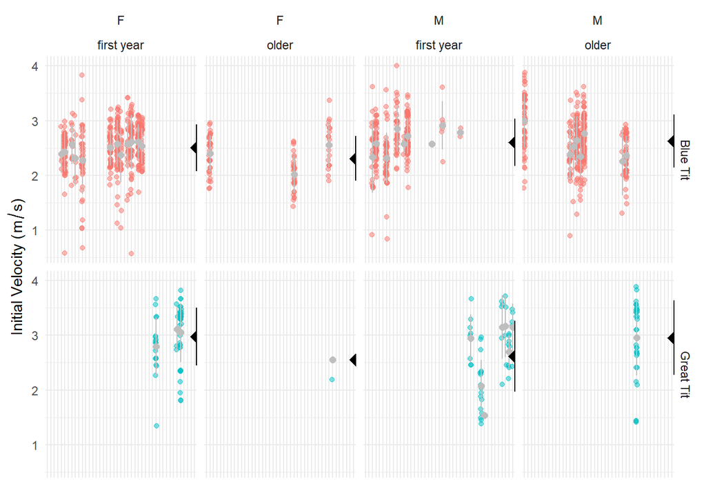

```r
# filtering out those without sex
nat.var_mf <- nat.var %>%
  filter(Sex != "")


summary_df <- nat.var_mf %>%
  group_by(Ring, species, Sex, age) %>%
  summarise(
    mean_v1 = mean(v1, na.rm = TRUE),
    sd_v1 = sd(v1, na.rm = TRUE),
    .groups = 'drop'
  ) %>%
  mutate(
    sd_lower = mean_v1 - sd_v1,
    sd_upper = mean_v1 + sd_v1
  )

species_summary <- nat.var_mf %>%
  group_by(species, Sex, age) %>%
  summarise(
    mean_v1 = mean(v1, na.rm = TRUE),
    sd_v1 = sd(v1, na.rm = TRUE),
    .groups = 'drop'
  ) %>%
  mutate(
    sd_lower = mean_v1 - sd_v1,
    sd_upper = mean_v1 + sd_v1
  )

plot_v1_agesex <- ggplot(nat.var_mf, aes(x = Ring, y = v1)) +
  geom_jitter(width = 0.2, alpha = 0.5, aes(color = species)) +
  geom_point(data = summary_df, aes(x = Ring, y = mean_v1), color = "grey", size = 2, shape = 16, inherit.aes = FALSE) +

  geom_errorbar(data = summary_df, aes(x = Ring, ymin = sd_lower, ymax = sd_upper), color = "grey", width = 0.2,
  inherit.aes = FALSE) +

  geom_point(data = species_summary, aes(x = Inf - 0.5, y = mean_v1), color = "black", size = 4, shape = 18,
  inherit.aes = FALSE) +

  geom_errorbar(data = species_summary, aes(x = Inf - 0.5, ymin = sd_lower, ymax = sd_upper), color = "black", width = 0.4, inherit.aes = FALSE) +
  facet_grid(species ~ Sex + age, labeller = labeller(
    species = c("bluti" = "Blue Tit", "greti" = "Great Tit", "marti" = "Marsh Tit"),
    Sex = label_value,
    age = c("5" = "first year", "6" = "older")
  )) +
  theme_minimal() +
  labs(
    x = "",
    y = expression("Initial Velocity ("*m/s*")")
  ) +
  theme(
    axis.text.x = element_blank(),
    axis.ticks.x = element_blank(),
    legend.position = "none"
  )

plot_v1_agesex
```

### acc by species, age, and sex.

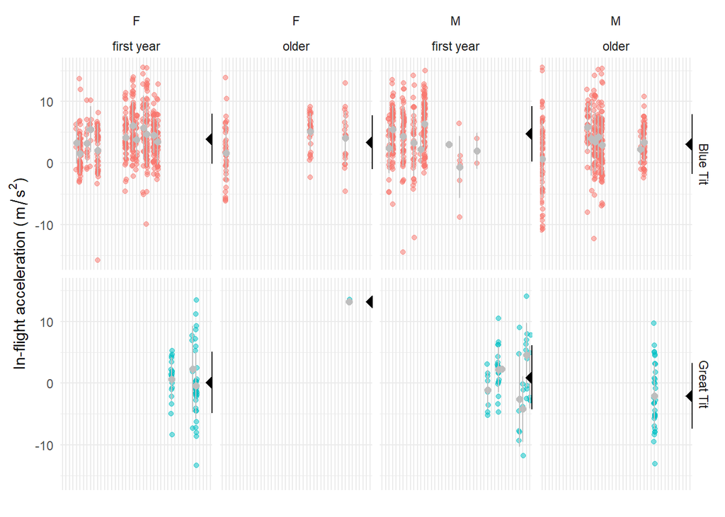

```r
# filtering out those without sex
nat.var_mf <- nat.var %>%
  filter(Sex != "")


summary_df <- nat.var_mf %>%
  group_by(Ring, species, Sex, age) %>%
  summarise(
    mean_acc = mean(acc, na.rm = TRUE),
    sd_acc = sd(acc, na.rm = TRUE),
    .groups = 'drop'
  ) %>%
  mutate(
    sd_lower = mean_acc - sd_acc,
    sd_upper = mean_acc + sd_acc
  )

species_summary <- nat.var_mf %>%
  group_by(species, Sex, age) %>%
  summarise(
    mean_acc = mean(acc, na.rm = TRUE),
    sd_acc = sd(acc, na.rm = TRUE),
    .groups = 'drop'
  ) %>%
  mutate(
    sd_lower = mean_acc - sd_acc,
    sd_upper = mean_acc + sd_acc
  )

plot_acc_agesex <- ggplot(nat.var_mf, aes(x = Ring, y = acc)) +
  geom_jitter(width = 0.2, alpha = 0.5, aes(color = species)) +
  geom_point(data = summary_df, aes(x = Ring, y = mean_acc), color = "grey", size = 2, shape = 16, inherit.aes = FALSE) +

  geom_errorbar(data = summary_df, aes(x = Ring, ymin = sd_lower, ymax = sd_upper), color = "grey", width = 0.2,
  inherit.aes = FALSE) +

  geom_point(data = species_summary, aes(x = Inf - 0.5, y = mean_acc), color = "black", size = 4, shape = 18,
  inherit.aes = FALSE) +

  geom_errorbar(data = species_summary, aes(x = Inf - 0.5, ymin = sd_lower, ymax = sd_upper), color = "black", width = 0.4, inherit.aes = FALSE) +
  facet_grid(species ~ Sex + age, labeller = labeller(
    species = c("bluti" = "Blue Tit", "greti" = "Great Tit", "marti" = "Marsh Tit"),
    Sex = label_value,
    age = c("5" = "first year", "6" = "older")
  )) +
  theme_minimal() +
  labs(
    x = "",
    y = expression("In-flight acceleration ("*m/s^2*")")
  ) +
  theme(
    axis.text.x = element_blank(),
    axis.ticks.x = element_blank(),
    legend.position = "none"
  )

plot_acc_agesex
```

- identify the only great tit adult female
- filter that superbird and see if the acceleration still shows interaction effect with sex and age

```r
super_ladybird <- nat.var_mf %>%
  filter((species == "greti") & (Sex == "F") & (age == 6))

super_ladybird$Ring
```

```
## [1] "TY68155"
```

```r
super_ladybird$acc
```

```
## [1] 13.19759
```

```r
nat.var_mf_ordinary <- nat.var_mf %>%
  filter(Ring != "TY68155")

#before
Anova(lmer(acc ~ species*Sex*age + headwind + (1|Ring), data = nat.var_mf), type = 3, test.statistic = "F")
```

```
## Analysis of Deviance Table (Type III Wald F tests with Kenward-Roger df)
##
## Response: acc
##                      F Df  Df.res   Pr(>F)
## (Intercept)     0.8297  1   28.41 0.370020
## species         8.2550  1  352.63 0.004310 **
## Sex             0.0023  1   29.61 0.961672
## age             0.1446  1   28.01 0.706572
## headwind        2.9884  1 1168.50 0.084125 .
## species:Sex     8.3596  1  184.76 0.004297 **
## species:age     7.6750  1  396.72 0.005862 **
## Sex:age         0.0002  1   29.16 0.989791
## species:Sex:age 8.6568  1  203.55 0.003636 **
## ---
## Signif. codes:  0 '***' 0.001 '**' 0.01 '*' 0.05 '.' 0.1 ' ' 1
```

```r
summary(lmer(acc ~ species*Sex*age + headwind + (1|Ring), data = nat.var_mf), type = 3)
```

```
## Linear mixed model fit by REML. t-tests use Satterthwaite's method [
## lmerModLmerTest]
## Formula: acc ~ species * Sex * age + headwind + (1 | Ring)
##    Data: nat.var_mf
##
## REML criterion at convergence: 7009
##
## Scaled residuals:
##     Min      1Q  Median      3Q     Max
## -4.4026 -0.6404 -0.0192  0.6199  3.3496
##
## Random effects:
##  Groups   Name        Variance Std.Dev.
##  Ring     (Intercept)  2.467   1.571
##  Residual             18.571   4.309
## Number of obs: 1211, groups:  Ring, 43
##
## Fixed effects:
##                         Estimate Std. Error         df t value Pr(>|t|)
## (Intercept)              5.49979    6.03018   27.20394   0.912  0.36976
## speciesgreti           -70.96612   24.69075  341.63910  -2.874  0.00430 **
## SexM                    -0.38453    7.90162   28.35635  -0.049  0.96153
## age                     -0.43863    1.15212   26.81848  -0.381  0.70641
## headwind                -0.22508    0.12979 1167.01627  -1.734  0.08315 .
## speciesgreti:SexM       78.76177   27.22251  177.90816   2.893  0.00429 **
## speciesgreti:age        13.48942    4.86785  384.97845   2.771  0.00586 **
## SexM:age                 0.01914    1.47761   27.92387   0.013  0.98976
## speciesgreti:SexM:age  -15.68757    5.32915  196.13856  -2.944  0.00363 **
## ---
## Signif. codes:  0 '***' 0.001 '**' 0.01 '*' 0.05 '.' 0.1 ' ' 1
##
## Correlation of Fixed Effects:
##             (Intr) spcsgr SexM   age    hedwnd spc:SM spcsg: SexM:g
## speciesgret -0.240
## SexM        -0.750  0.183
## age         -0.995  0.242  0.751
## headwind     0.079  0.037  0.003 -0.012
## spcsgrt:SxM  0.214 -0.907 -0.290 -0.218 -0.044
## specisgrt:g  0.232 -0.999 -0.178 -0.236 -0.037  0.906
## SexM:age     0.768 -0.187 -0.996 -0.773  0.001  0.289  0.183
## spcsgrt:SM: -0.210  0.912  0.276  0.214  0.042 -0.998 -0.913 -0.277
```

```r
#after
Anova(lmer(acc ~ species*Sex*age + headwind + (1|Ring), data = nat.var_mf_ordinary), type = 3, test.statistic = "F")
```

```
## fixed-effect model matrix is rank deficient so dropping 1 column / coefficient
```

```
## Analysis of Deviance Table (Type III Wald F tests with Kenward-Roger df)
##
## Response: acc
##                      F Df  Df.res  Pr(>F)
## (Intercept)     0.8297  1   28.41 0.37002
## species         0.4662  1   29.96 0.49999
## Sex             0.0023  1   29.61 0.96167
## age             0.1446  1   28.01 0.70657
## headwind        2.9884  1 1168.50 0.08413 .
## species:Sex     0.0369  1   40.20 0.84857
## species:age     1.0230  1   29.99 0.31990
## Sex:age         0.0002  1   29.16 0.98979
## species:Sex:age         0    0.00
## ---
## Signif. codes:  0 '***' 0.001 '**' 0.01 '*' 0.05 '.' 0.1 ' ' 1
```

```r
summary(lmer(acc ~ species*Sex*age + headwind + (1|Ring), data = nat.var_mf_ordinary), type = 3)
```

```
## fixed-effect model matrix is rank deficient so dropping 1 column / coefficient
```

```
## Linear mixed model fit by REML. t-tests use Satterthwaite's method [
## lmerModLmerTest]
## Formula: acc ~ species * Sex * age + headwind + (1 | Ring)
##    Data: nat.var_mf_ordinary
##
## REML criterion at convergence: 7009
##
## Scaled residuals:
##     Min      1Q  Median      3Q     Max
## -4.4026 -0.6415 -0.0199  0.6204  3.3496
##
## Random effects:
##  Groups   Name        Variance Std.Dev.
##  Ring     (Intercept)  2.467   1.571
##  Residual             18.571   4.309
## Number of obs: 1210, groups:  Ring, 42
##
## Fixed effects:
##                     Estimate Std. Error         df t value Pr(>|t|)
## (Intercept)          5.49979    6.03018   27.20394   0.912   0.3698
## speciesgreti         7.47171   10.92766   28.68829   0.684   0.4996
## SexM                -0.38453    7.90162   28.35636  -0.049   0.9615
## age                 -0.43863    1.15212   26.81849  -0.381   0.7064
## headwind            -0.22508    0.12979 1167.01627  -1.734   0.0832 .
## speciesgreti:SexM    0.32393    1.67787   38.50712   0.193   0.8479
## speciesgreti:age    -2.19815    2.17016   28.71478  -1.013   0.3196
## SexM:age             0.01913    1.47761   27.92388   0.013   0.9898
## ---
## Signif. codes:  0 '***' 0.001 '**' 0.01 '*' 0.05 '.' 0.1 ' ' 1
##
## Correlation of Fixed Effects:
##             (Intr) spcsgr SexM   age    hedwnd spc:SM spcsg:
## speciesgret -0.031
## SexM        -0.750 -0.260
## age         -0.995  0.026  0.751
## headwind     0.079 -0.020  0.003 -0.012
## spcsgrt:SxM  0.150  0.258 -0.323 -0.133 -0.037
## specisgrt:g  0.007 -0.993  0.279 -0.005  0.020 -0.346
## SexM:age     0.768  0.252 -0.996 -0.773  0.001  0.288 -0.270
## fit warnings:
## fixed-effect model matrix is rank deficient so dropping 1 column / coefficient
```

```r
# the interaction effect disappears when the one extraordinary flight of adult female is excluded.
```

- acc: great tit mean & great tit female mean

```r
great_tit_overall <- nat.var_mf_ordinary %>%
  filter(species == "greti") %>%
  summarise(
    mean_acc = mean(acc, na.rm = TRUE),
    sd_acc = sd(acc, na.rm = TRUE)
  )

great_tit_female <- nat.var_mf_ordinary %>%
  filter(species == "greti", Sex == "F") %>%
  summarise(
    mean_acc = mean(acc, na.rm = TRUE),
    sd_acc = sd(acc, na.rm = TRUE)
  )

great_tit_overall
```

```
##     mean_acc   sd_acc
## 1 -0.1059099 5.201099
```

```r
great_tit_female
```

```
##     mean_acc   sd_acc
## 1 0.09879925 4.940885
```

## 4. temporal resolution

- filtering the flights with the same or better temporal resolution of 0.013 s

```r
nat.var$temp_res <- (1/nat.var$v1)*0.03
mean(nat.var$temp_res)
```

```
## [1] 0.0122397
```

```r
sd(nat.var$temp_res)
```

```
## [1] 0.003613301
```

```r
min(nat.var$temp_res)
```

```
## [1] 0.0075
```

```r
max(nat.var$temp_res)
```

```
## [1] 0.0525
```

```r
nat.var_temp_res <- nat.var %>%
  filter(temp_res <= 0.013)
```

### v1

```r
Anova(lmer(v1 ~ species  + Sex  + age + headwind + (1|Ring), data = nat.var_temp_res), type = 3, test.statistic = "F")
```

```
## Analysis of Deviance Table (Type III Wald F tests with Kenward-Roger df)
##
## Response: v1
##                   F Df  Df.res    Pr(>F)
## (Intercept) 83.6283  1   36.50 5.618e-11 ***
## species     13.1216  2   36.56 5.066e-05 ***
## Sex          0.8147  2   35.35    0.4509
## age          0.0035  1   37.89    0.9531
## headwind     0.5634  1 1027.73    0.4531
## ---
## Signif. codes:  0 '***' 0.001 '**' 0.01 '*' 0.05 '.' 0.1 ' ' 1
```

```r
summary(lmer(v1 ~ species  + Sex  + age + headwind + (1|Ring), data = nat.var_temp_res), type = 3)
```

```
## Linear mixed model fit by REML. t-tests use Satterthwaite's method [
## lmerModLmerTest]
## Formula: v1 ~ species + Sex + age + headwind + (1 | Ring)
##    Data: nat.var_temp_res
##
## REML criterion at convergence: 494.1
##
## Scaled residuals:
##     Min      1Q  Median      3Q     Max
## -2.7305 -0.7275 -0.0502  0.6327  3.8165
##
## Random effects:
##  Groups   Name        Variance Std.Dev.
##  Ring     (Intercept) 0.01334  0.1155
##  Residual             0.08690  0.2948
## Number of obs: 1035, groups:  Ring, 48
##
## Fixed effects:
##                Estimate Std. Error         df t value Pr(>|t|)
## (Intercept)   2.646e+00  2.884e-01  3.481e+01   9.176 8.06e-11 ***
## speciesgreti  2.854e-01  5.622e-02  4.346e+01   5.076 7.71e-06 ***
## speciesmarti  1.207e-01  1.152e-01  2.882e+01   1.048    0.303
## SexF          2.816e-02  9.826e-02  2.886e+01   0.287    0.777
## SexM          8.132e-02  9.720e-02  2.876e+01   0.837    0.410
## age           2.955e-03  4.975e-02  3.613e+01   0.059    0.953
## headwind     -7.161e-03  9.523e-03  1.028e+03  -0.752    0.452
## ---
## Signif. codes:  0 '***' 0.001 '**' 0.01 '*' 0.05 '.' 0.1 ' ' 1
##
## Correlation of Fixed Effects:
##             (Intr) spcsgr spcsmr SexF   SexM   age
## speciesgret -0.198
## speciesmart -0.441  0.042
## SexF        -0.416 -0.068  0.762
## SexM        -0.275 -0.144  0.739  0.885
## age         -0.943  0.207  0.201  0.128 -0.022
## headwind     0.104 -0.029 -0.011 -0.010  0.006  0.003
```

### acc

```r
Anova(lmer(acc ~ species  + Sex  + age + headwind + (1|Ring), data = nat.var_temp_res), type = 3, test.statistic = "F")
```

```
## Analysis of Deviance Table (Type III Wald F tests with Kenward-Roger df)
##
## Response: acc
##                  F Df  Df.res   Pr(>F)
## (Intercept) 1.4809  1   37.06 0.231323
## species     7.7590  2   36.89 0.001539 **
## Sex         0.2961  2   36.03 0.745525
## age         0.9396  1   38.40 0.338450
## headwind    5.9720  1 1028.00 0.014702 *
## ---
## Signif. codes:  0 '***' 0.001 '**' 0.01 '*' 0.05 '.' 0.1 ' ' 1
```

```r
summary(lmer(acc ~ species  + Sex  + age + headwind + (1|Ring), data = nat.var_temp_res), type = 3)
```

```
## Linear mixed model fit by REML. t-tests use Satterthwaite's method [
## lmerModLmerTest]
## Formula: acc ~ species + Sex + age + headwind + (1 | Ring)
##    Data: nat.var_temp_res
##
## REML criterion at convergence: 5884
##
## Scaled residuals:
##     Min      1Q  Median      3Q     Max
## -4.1370 -0.5979 -0.0149  0.6544  3.7802
##
## Random effects:
##  Groups   Name        Variance Std.Dev.
##  Ring     (Intercept)  2.915   1.707
##  Residual             16.381   4.047
## Number of obs: 1035, groups:  Ring, 48
##
## Fixed effects:
##                Estimate Std. Error         df t value Pr(>|t|)
## (Intercept)     5.10185    4.17901   32.88796   1.221 0.230832
## speciesgreti   -3.15401    0.81030   40.51877  -3.892 0.000362 ***
## speciesmarti   -1.45028    1.67826   27.22316  -0.864 0.395052
## SexF            0.43549    1.43160   27.30264   0.304 0.763282
## SexM           -0.08367    1.41637   27.19708  -0.059 0.953326
## age            -0.70056    0.72026   34.08564  -0.973 0.337584
## headwind       -0.32074    0.13102 1028.00000  -2.448 0.014531 *
## ---
## Signif. codes:  0 '***' 0.001 '**' 0.01 '*' 0.05 '.' 0.1 ' ' 1
##
## Correlation of Fixed Effects:
##             (Intr) spcsgr spcsmr SexF   SexM   age
## speciesgret -0.202
## speciesmart -0.443  0.043
## SexF        -0.417 -0.067  0.763
## SexM        -0.281 -0.144  0.741  0.887
## age         -0.942  0.211  0.201  0.127 -0.019
## headwind     0.101 -0.030 -0.011 -0.010  0.006  0.001
```

-species is still significant! - however the 0.013s time difference came from the original 1434 flights data.

```r
dim(nat.var_temp_res)
```

```
## [1] 1035   39
```

```r
unique(nat.var_temp_res$Ring) #48 individuals
```

```
##  [1] "ATR8387" "AJY2668" "ATR5146" "ATR8380" "ATR8395" "ATR8819" "ATR6168"
##  [8] "ATR8383" "PF72506" "ATR6592" "ATR8375" "ATR8817" "ATR8372" "AJY3723"
## [15] "ATR5138" "VZ33440" "AVL4513" "AJY2672" "AJY3327" "PF72049" "ATR8822"
## [22] "AFH2869" "ATR5368" "AJY3812" "VZ33469" "VZ33439" "ATR6169" "ATR8803"
## [29] "ATR5147" "AFH5509" "AJY2661" "AVL6553" "VZ31785" "PF71274" "AJY2673"
## [36] "ATR8393" "AJY3272" "VZ33402" "AJY2666" "VZ31790" "ATR5177" "S884849"
## [43] "ATR8378" "ATR5306" "ATR8813" "AJY2356" "PF72738" "TY68155"
```

- comparing the exit time again in this dataset

```r
new_exit_time <- nat.var_temp_res %>%
  group_by(species) %>%
  summarise(
    mean_t1 = mean(t1, na.rm = TRUE),
    sd_t1 = sd(t1, na.rm = TRUE)
  )
new_exit_time
```

```
## # A tibble: 3 × 3
##   species mean_t1 sd_t1
##   <chr>     <dbl> <dbl>
## 1 bluti      95.5  9.74
## 2 greti      86.3 12.3
## 3 marti      94.1  9.93
```

## 5. bodyweight

- bare in mind these are not bodyweight at the time of flight but rather bodyweight that was ever measured of that individual through mist-netting

```r
# calculate mean and sd of bodyweight per species
bw_species <- nat.var %>%
  group_by(species) %>%
  summarise(
    n = n(),
    mean_bodyweight = mean(Wt, na.rm = TRUE),
    sd_bodyweight = sd(Wt, na.rm = TRUE)
  )
bw_species
```

```
## # A tibble: 3 × 4
##   species     n mean_bodyweight sd_bodyweight
##   <chr>   <int>           <dbl>         <dbl>
## 1 bluti    1172            10.8         0.597
## 2 greti     148            18.5         0.703
## 3 marti     114            10.2         0.481
```